# 04_Exploratory_Data_Analysis

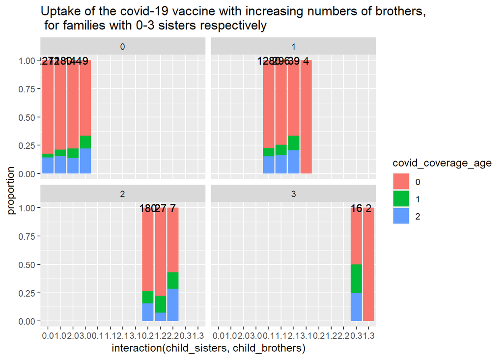

```r
cov_covereage_age_brothers_sisters |>
  mutate(sum_by_sisters = sum(count), .by = c(child_sisters, child_brothers)) |>
  ggplot() +
  geom_col(aes(x = interaction(child_sisters, child_brothers), y = proportion, fill = covid_coverage_age), position = "fill") +
  geom_text(aes(x = interaction(child_sisters, child_brothers), y = 1, label = sum_by_sisters)) +
  facet_wrap(vars(child_brothers)) +
  ggtitle("Uptake of the covid-19 vaccine with increasing numbers of brothers, \n for families with 0-3 sisters respectively")
```

*2. The uptake of the influenza vaccine in children of interest*

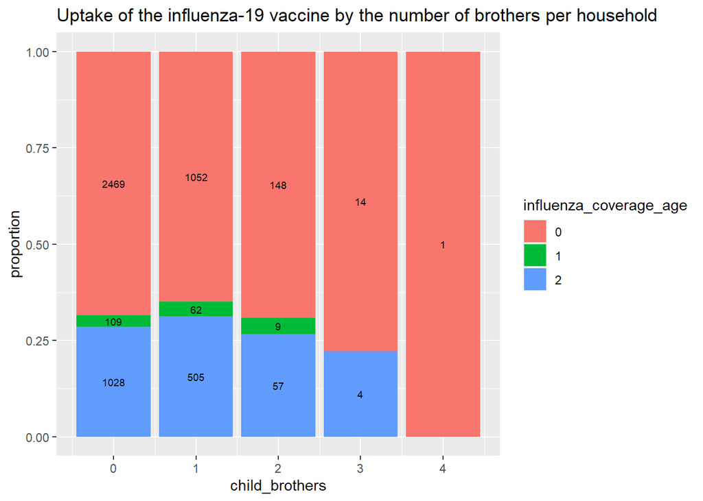

```r
inf_ivd |>
  filter(!is.na(influenza_coverage_age) & !is.na(child_brothers)) |>
  summarise(count = n(), .by = c(influenza_coverage_age, child_brothers)) |>
  mutate(proportion = count / sum(count), .by = child_brothers) -> inf_coverage_age_brothers

inf_ivd |>
  filter(!is.na(influenza_coverage_age) & !is.na(child_sisters)) |>
  summarise(count = n(), .by = c(influenza_coverage_age, child_sisters)) |>
  mutate(proportion = count / sum(count), .by = child_sisters) -> inf_coverage_age_sisters

inf_ivd |>
  filter(!is.na(influenza_coverage_age) & child_brothers <= 3 & child_sisters <= 3) |>
  summarise(count = n(), .by = c(influenza_coverage_age, child_sisters, child_brothers)) |>
  mutate(proportion = count / sum(count), .by = c(child_sisters, child_brothers)) -> inf_coverage_age_brothers_sisters

inf_coverage_age_brothers |>
  ggplot() +
  geom_col(aes(x = child_brothers, y = proportion, fill = influenza_coverage_age), position = "fill") +
  geom_text(aes(x = child_brothers, y = proportion, label = count, group = influenza_coverage_age), position = position_fill(vjust = 0.5), size = 2.5) +
  ggtitle("Uptake of the influenza-19 vaccine by the number of brothers per household")
```

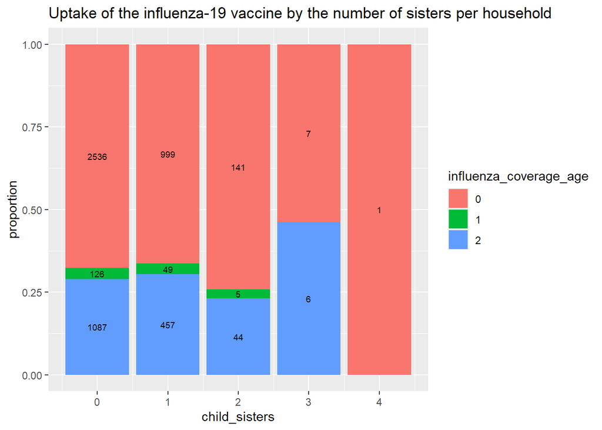

```r
inf_coverage_age_sisters |>
  ggplot() +
  geom_col(aes(x = child_sisters, y = proportion, fill = influenza_coverage_age), position = "fill") +
  geom_text(aes(x = child_sisters, y = proportion, label = count, group = influenza_coverage_age), position = position_fill(vjust = 0.5), size = 2.5) +
  ggtitle("Uptake of the influenza-19 vaccine by the number of sisters per household")
```

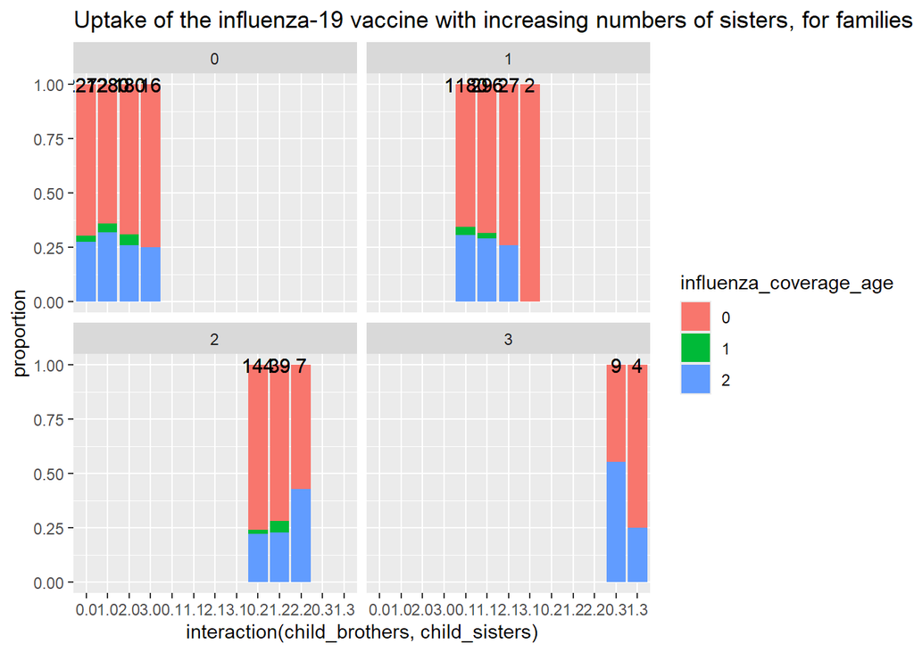

```r
inf_coverage_age_brothers_sisters |>
  mutate(sum_by_brothers = sum(count), .by = c(child_brothers, child_sisters)) |>
  ggplot() +
  geom_col(aes(x = interaction(child_brothers, child_sisters), y = proportion, fill = influenza_coverage_age), position = "fill") +
  geom_text(aes(x = interaction(child_brothers, child_sisters), y = 1, label = sum_by_brothers)) +
  facet_wrap(vars(child_sisters)) +
  ggtitle("Uptake of the influenza-19 vaccine with increasing numbers of sisters, for families with 0-3 brothers respectively")
```

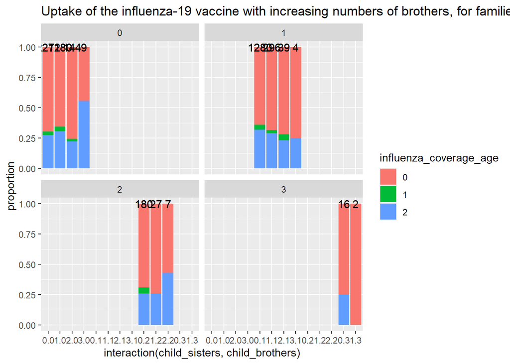

```r
inf_coverage_age_brothers_sisters |>
  mutate(sum_by_sisters = sum(count), .by = c(child_sisters, child_brothers)) |>
  ggplot() +
  geom_col(aes(x = interaction(child_sisters, child_brothers), y = proportion, fill = influenza_coverage_age), position = "fill") +
  geom_text(aes(x = interaction(child_sisters, child_brothers), y = 1, label = sum_by_sisters)) +
  facet_wrap(vars(child_brothers)) +
  ggtitle("Uptake of the influenza-19 vaccine with increasing numbers of brothers, for families with 0-3 sisters respectively")
```

### Number of siblings at the time of vaccination

### Age of the child

The following is a summary of the ages of the children of interest

```r
cov_ivd |>
  select(age_of_interest) |>
  fivenum()
```

```
[1] -0.08213552  3.05270363  6.82409309 12.85284052 17.99315537
```

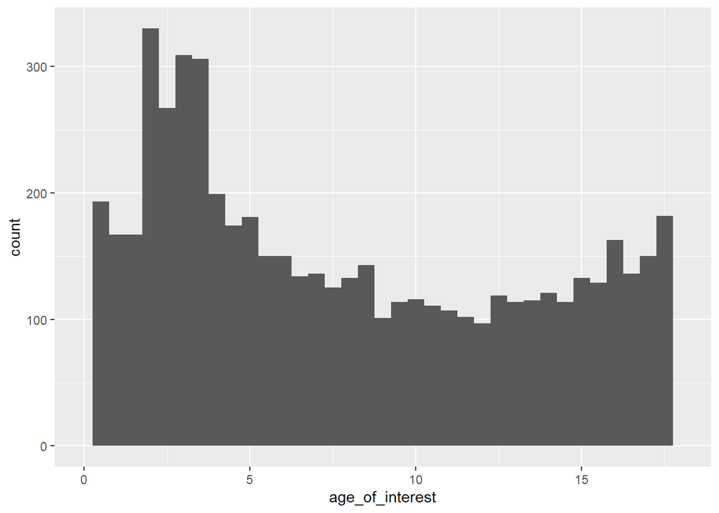

```r
# distribution of number of children across age groups
cov_ivd |>
  filter(!is.na(age_of_interest)) |>
  ggplot() +
  geom_histogram(aes(x = age_of_interest), binwidth = 0.5) +
  xlim(0,18)
```

*How does the age of the COI impact their uptake of:* *1. The covid-19 vaccination* Looking at the whole child population as a whole (0-18 y/o) we examine the proportion of children that make up each respective age and coverage group for the covid vaccine

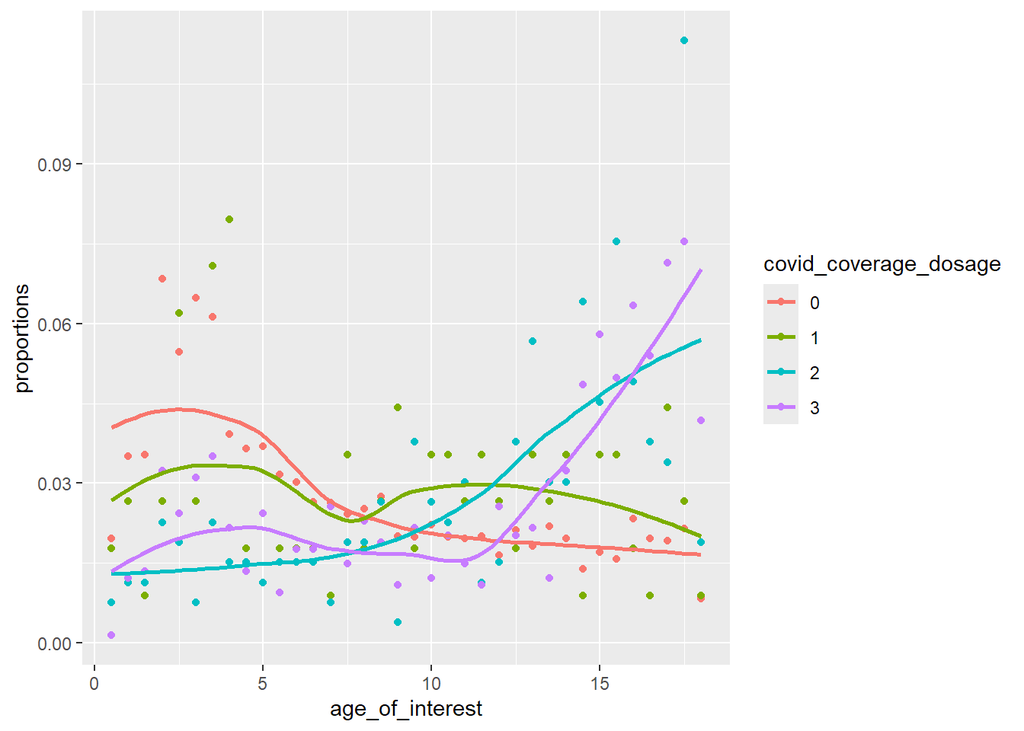

```r
# how each age takes up a different proprotion of the respective vax (doesn't account for differences in sizes of ages)
cov_ivd |>
  filter(!is.na(covid_coverage_dosage)) |>
  mutate(age_of_interest = round(age_of_interest * 2) / 2) -> cov_COI_age_whole

# plot the proportion of the total no. of COI children of each age_of_interest and each dosage represent
cov_COI_age_whole |>
  summarise(count = n(), .by = c(age_of_interest, covid_coverage_dosage)) |>
  mutate(proportions = count/sum(count), .by = covid_coverage_dosage) |>
  arrange(age_of_interest, covid_coverage_dosage) |>
  ggplot(aes(x = age_of_interest, y = proportions)) +
  geom_point(aes(colour = covid_coverage_dosage)) +
  geom_smooth(aes(colour = covid_coverage_dosage), method = "loess", se = FALSE)
```

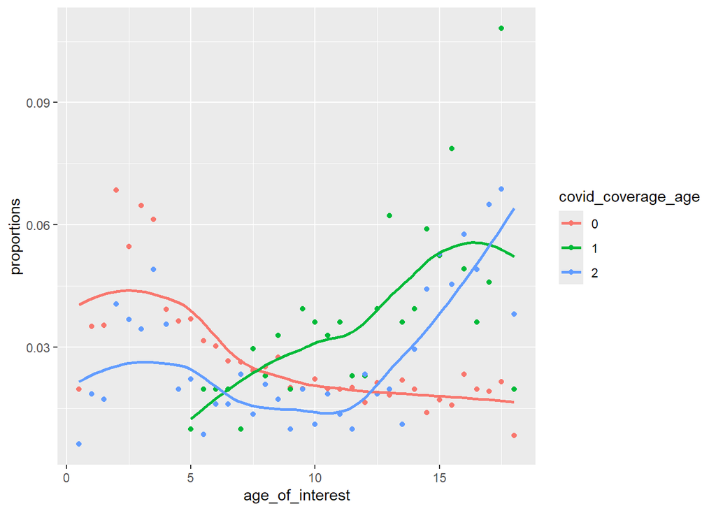

```r
# plot the proportion of the total no. of COI children of each age_of_interest and each degree of coverage represent
cov_COI_age_whole |>
  summarise(count = n(), .by = c(age_of_interest, covid_coverage_age)) |>
  mutate(proportions = count/sum(count), .by = covid_coverage_age) |>
  arrange(age_of_interest, covid_coverage_age) |>
  ggplot(aes(x = age_of_interest, y = proportions)) +
  geom_point(aes(colour = covid_coverage_age)) +
  geom_smooth(aes(colour = covid_coverage_age), method = "loess", se = FALSE)
```

- Interestingly, the proportion of individuals from 2-4 y/o is extremely high though this is explained by there being a greater proportion of children who fall into that group

Examining how the proportion of children with the no. of covid doses and the degree of coverage by the covid vaccine varies with the child’s age

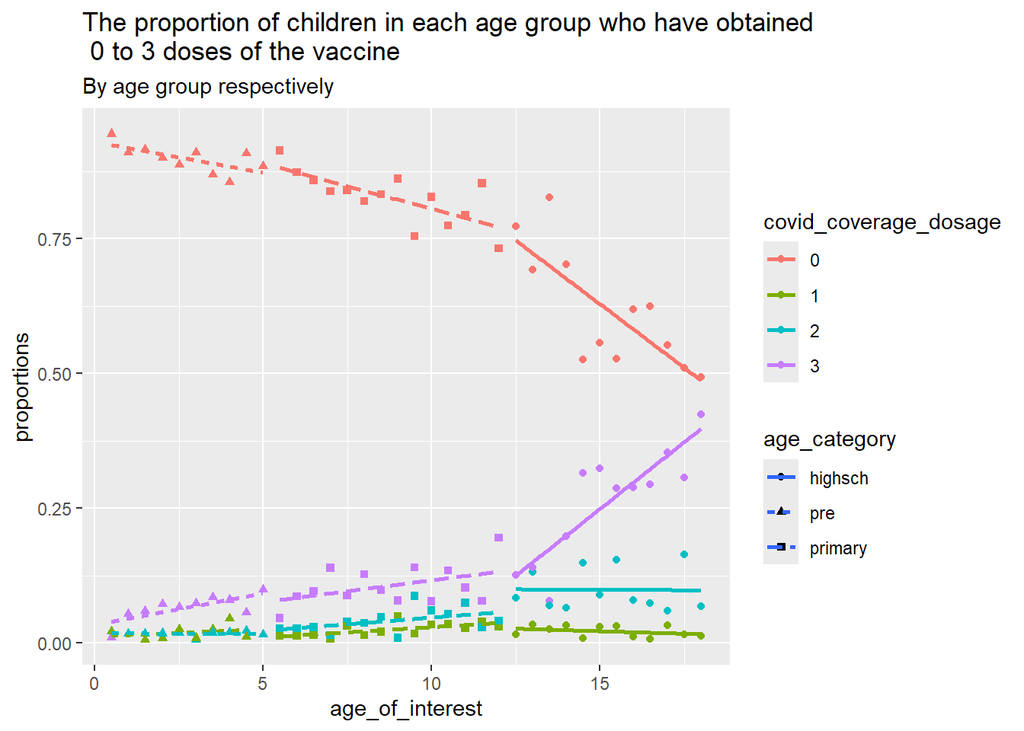

```r
# how each dosage takes up a different proportion of the respective age (accounts for differences in sizes of ages)
cov_ivd |>
  filter(!is.na(covid_coverage_dosage)) |>
  mutate(age_of_interest = round(age_of_interest * 2) / 2) -> cov_COI_age_age

cov_COI_age_age |>
  summarise(count = n(), .by = c(age_of_interest, covid_coverage_dosage)) |>
  mutate(proportions = count/sum(count), .by = age_of_interest) |>
  mutate(
    age_category = factor(
    case_when(
    age_of_interest %in% seq(0, 5, by = 0.5) ~ "pre",
    age_of_interest %in% seq(5.5, 12, by = 0.5) ~ "primary",
    age_of_interest %in% seq(12.5, 18, by = 0.5) ~ "highsch"
    ))
  ) |>

  ggplot() +
  geom_point(aes(x = age_of_interest, y = proportions, colour = covid_coverage_dosage, shape = age_category)) +
  geom_smooth(aes(x = age_of_interest, y = proportions, colour = covid_coverage_dosage, linetype = age_category), method = "lm", se = FALSE) +
  labs(title = "The proportion of children in each age group who have obtained \n 0 to 3 doses of the vaccine", subtitle = "By age group respectively")
```

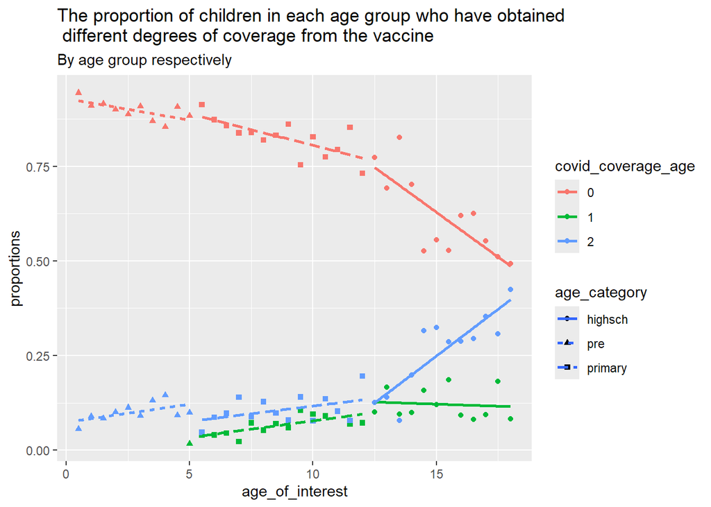

```r
cov_COI_age_age |>
  summarise(count = n(), .by = c(age_of_interest, covid_coverage_age)) |>
  mutate(proportions = count/sum(count), .by = age_of_interest) |>
  mutate(
    age_category = factor(
    case_when(
    age_of_interest %in% seq(0, 5, by = 0.5) ~ "pre",
    age_of_interest %in% seq(5.5, 12, by = 0.5) ~ "primary",
    age_of_interest %in% seq(12.5, 18, by = 0.5) ~ "highsch"
    ))
  ) |>

  ggplot() +
  geom_point(aes(x = age_of_interest, y = proportions, colour = covid_coverage_age, shape = age_category)) +
  geom_smooth(aes(x = age_of_interest, y = proportions, colour = covid_coverage_age, linetype = age_category), method = "lm", se = FALSE) +
  labs(title = "The proportion of children in each age group who have obtained \n different degrees of coverage from the vaccine", subtitle = "By age group respectively")
```

*How does the age of the COI impact their uptake of:* *2. The Influenza vaccination*

Looking at the whole child population as a whole (0-18 y/o) we examine the proportion of children that make up each respective age and coverage group for the influenza vaccine

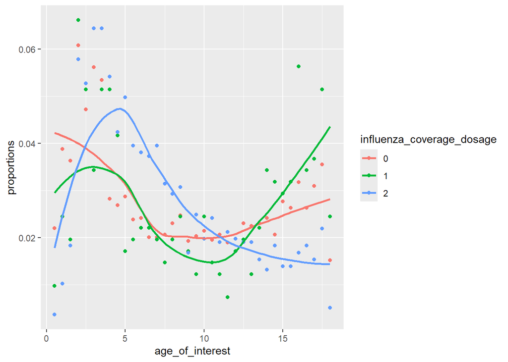

```r
# how each age takes up a different proprotion of the respective vax (doesn't account for differences in sizes of ages)
inf_ivd |>
  filter(!is.na(influenza_coverage_dosage)) |>
  mutate(age_of_interest = round(age_of_interest * 2) / 2) -> inf_COI_age_whole

# plot the proportion of the total no. of COI children of each age_of_interest and each dosage represent
inf_COI_age_whole |>
  summarise(count = n(), .by = c(age_of_interest, influenza_coverage_dosage)) |>
  mutate(proportions = count/sum(count), .by = influenza_coverage_dosage) |>
  arrange(age_of_interest, influenza_coverage_dosage) |>
  ggplot(aes(x = age_of_interest, y = proportions)) +
  geom_point(aes(colour = influenza_coverage_dosage)) +
  geom_smooth(aes(colour = influenza_coverage_dosage), method = "loess", se = FALSE)
```

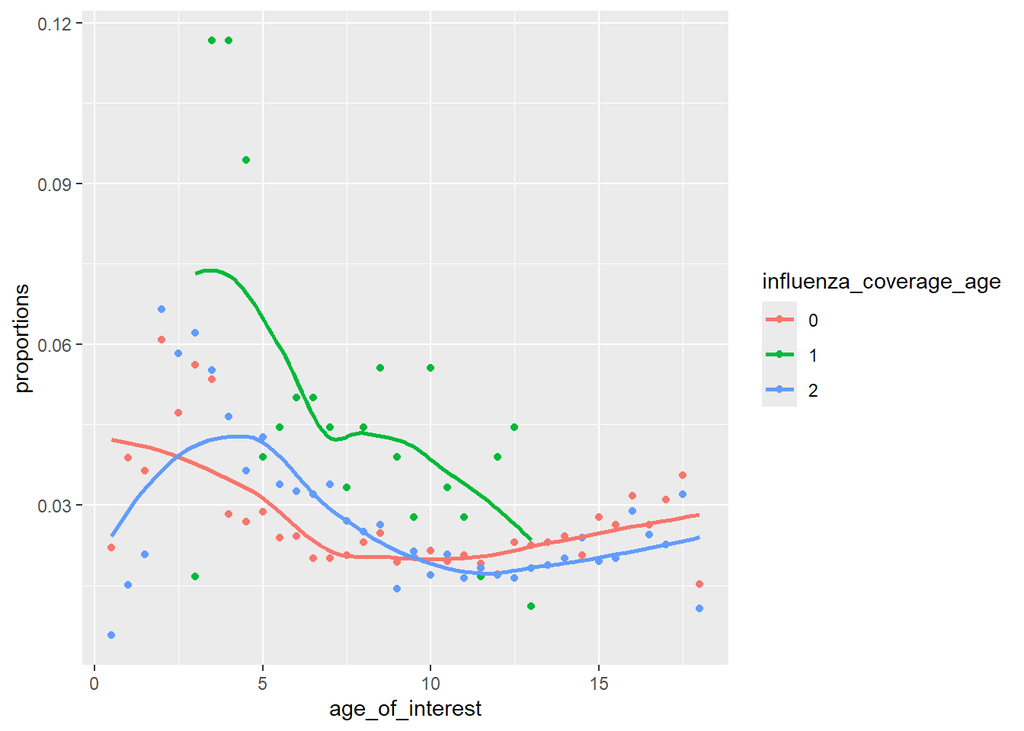

```r
# plot the proportion of the total no. of COI children of each age_of_interest and each degree of coverage represent
inf_COI_age_whole |>
  summarise(count = n(), .by = c(age_of_interest, influenza_coverage_age)) |>
  mutate(proportions = count/sum(count), .by = influenza_coverage_age) |>
  arrange(age_of_interest, influenza_coverage_age) |>
  ggplot(aes(x = age_of_interest, y = proportions)) +
  geom_point(aes(colour = influenza_coverage_age)) +
  geom_smooth(aes(colour = influenza_coverage_age), method = "loess", se = FALSE)
```

Examining how the proportion of children with the no. of influenza doses and the degree of coverage by the influenza vaccine varies with the child’s age

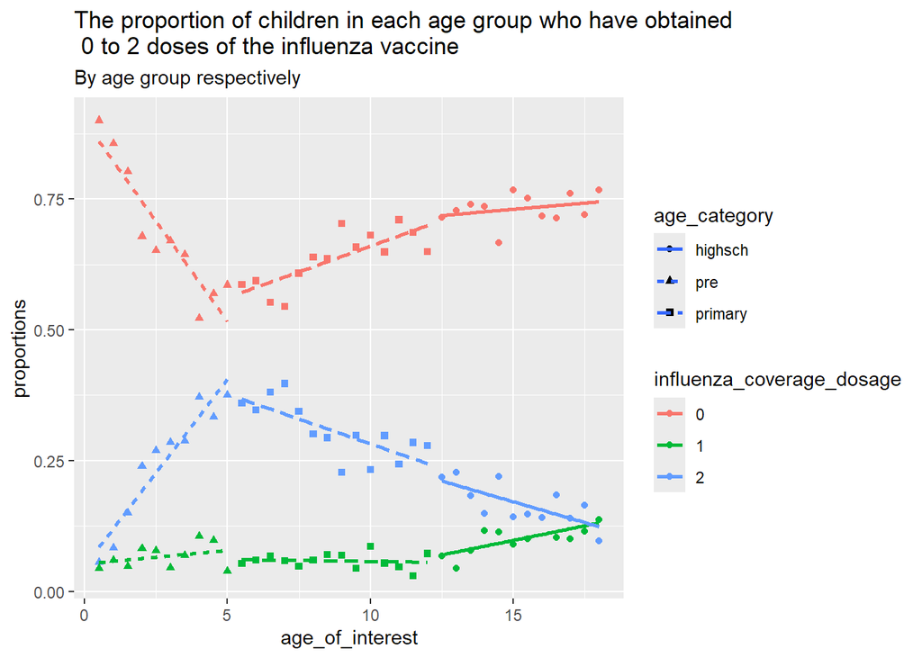

```r
# how each dosage takes up a different proportion of the respective age (accounts for differences in sizes of ages)
inf_ivd |>
  filter(!is.na(influenza_coverage_dosage)) |>
  mutate(age_of_interest = round(age_of_interest * 2) / 2) -> inf_COI_age_age

inf_COI_age_age |>
  summarise(count = n(), .by = c(age_of_interest, influenza_coverage_dosage)) |>
  mutate(proportions = count/sum(count), .by = age_of_interest) |>
  mutate(
    age_category = factor(
    case_when(
    age_of_interest %in% seq(0, 5, by = 0.5) ~ "pre",
    age_of_interest %in% seq(5.5, 12, by = 0.5) ~ "primary",
    age_of_interest %in% seq(12.5, 18, by = 0.5) ~ "highsch"
    ))
  ) |>

  ggplot() +
  geom_point(aes(x = age_of_interest, y = proportions, colour = influenza_coverage_dosage, shape = age_category)) +
  geom_smooth(aes(x = age_of_interest, y = proportions, colour = influenza_coverage_dosage, linetype = age_category), method = "lm", se = FALSE) +
  labs(title = "The proportion of children in each age group who have obtained \n 0 to 2 doses of the influenza vaccine", subtitle = "By age group respectively")
```

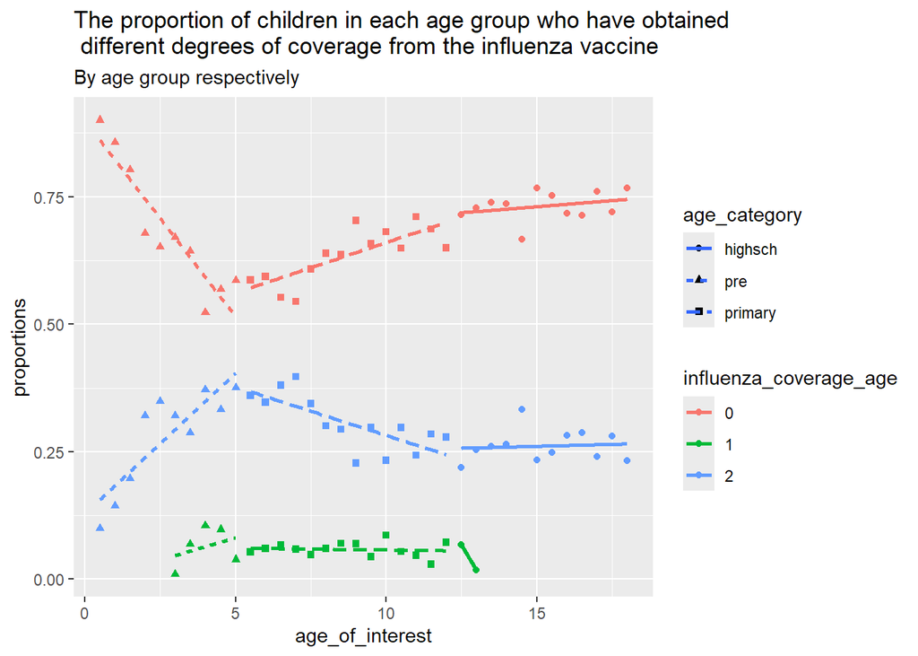

```r
inf_COI_age_age |>
  summarise(count = n(), .by = c(age_of_interest, influenza_coverage_age)) |>
  mutate(proportions = count/sum(count), .by = age_of_interest) |>
  mutate(
    age_category = factor(
    case_when(
    age_of_interest %in% seq(0, 5, by = 0.5) ~ "pre",
    age_of_interest %in% seq(5.5, 12, by = 0.5) ~ "primary",
    age_of_interest %in% seq(12.5, 18, by = 0.5) ~ "highsch"
    ))
  ) |>

  ggplot() +
  geom_point(aes(x = age_of_interest, y = proportions, colour = influenza_coverage_age, shape = age_category)) +
  geom_smooth(aes(x = age_of_interest, y = proportions, colour = influenza_coverage_age, linetype = age_category), method = "lm", se = FALSE) +
  labs(title = "The proportion of children in each age group who have obtained \n different degrees of coverage from the influenza vaccine", subtitle = "By age group respectively")
```

There is a peak in the influenza vaccination (give it’s yearly) for children who are going into primary school

### Gender of the child

*investigating how the gender of the child of interest affects their uptake of:* **1. the covid vaccine**

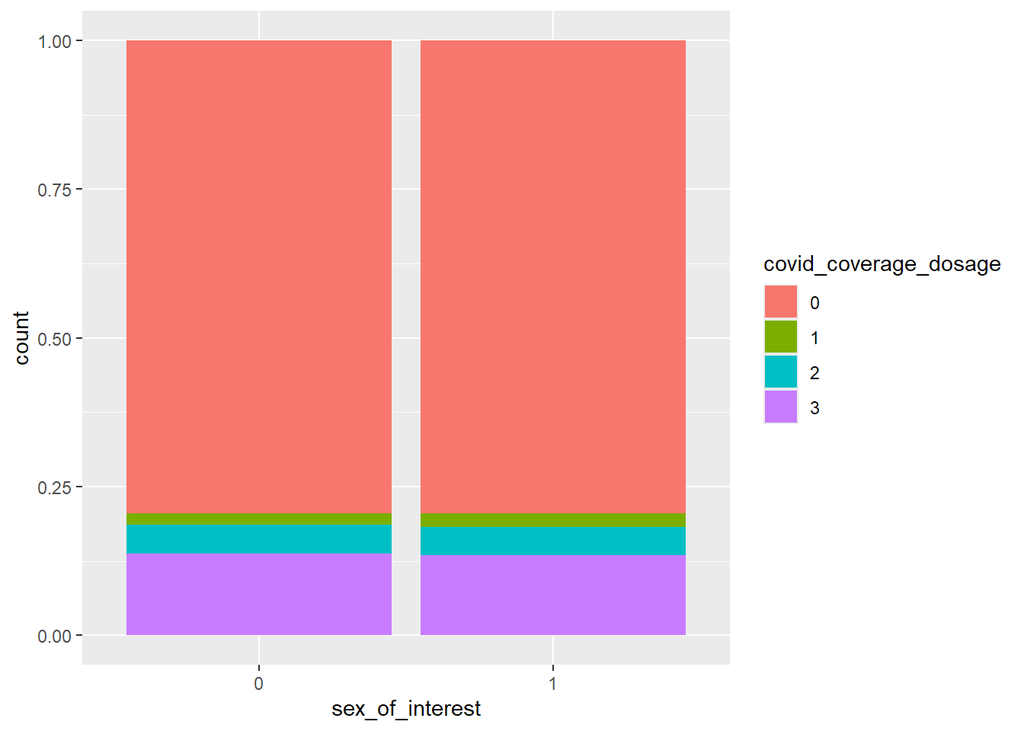

```r
cov_ivd |>
  filter(!is.na(covid_coverage_dosage)) |>
  summarise(count = n(), .by = c(covid_coverage_dosage, sex_of_interest)) |>

  ggplot() +
  geom_col(aes(x = sex_of_interest, y = count, fill = covid_coverage_dosage), position = "fill")
```

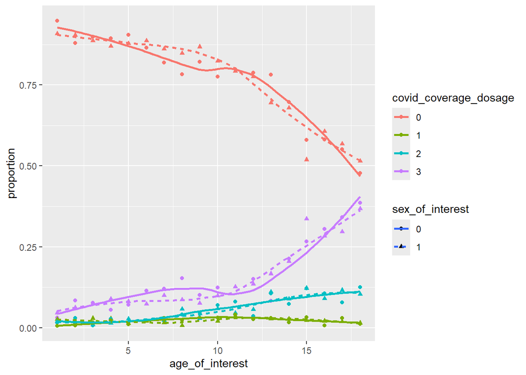

```r
cov_ivd |>
  filter(!is.na(covid_coverage_dosage)) |>
  mutate(age_of_interest = round(age_of_interest)) |>
  summarise(count = n(), .by = c(covid_coverage_dosage, sex_of_interest, age_of_interest)) |>
  mutate(proportion = count/sum(count), .by = c(age_of_interest, sex_of_interest)) -> cov_sex_age_dosage

cov_sex_age_dosage |>
  ggplot() +
  geom_point(aes(x = age_of_interest, y = proportion, shape = sex_of_interest, colour = covid_coverage_dosage)) +
  geom_smooth(aes(x = age_of_interest, y = proportion, linetype = sex_of_interest, colour = covid_coverage_dosage), se = FALSE)
```

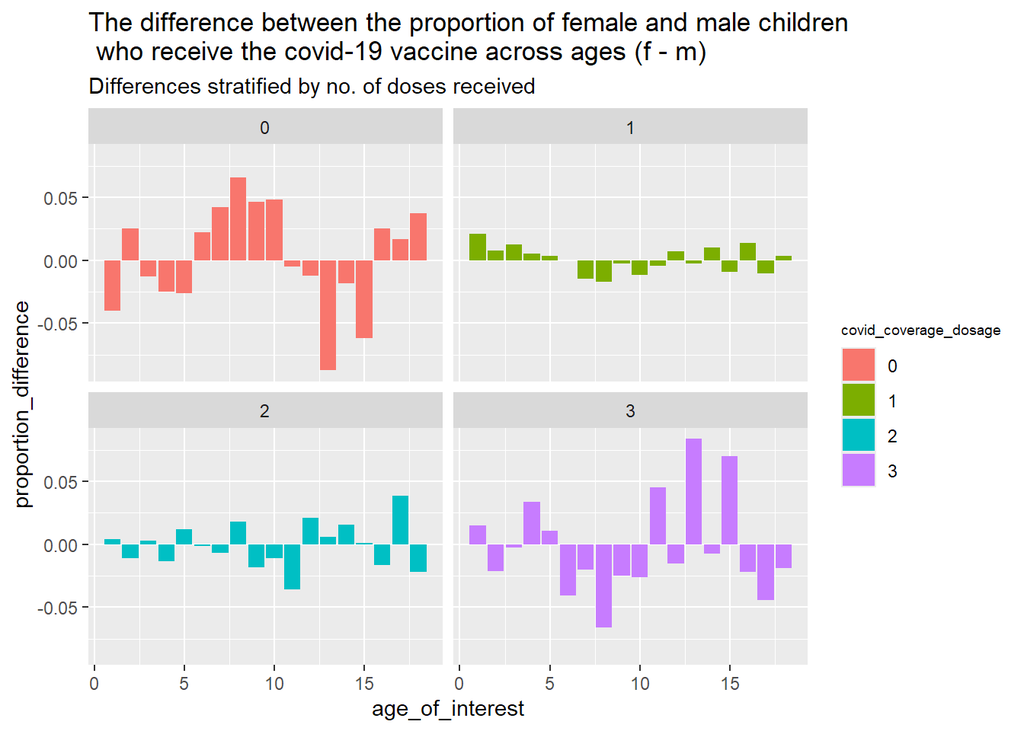

```r
cov_sex_age_dosage |>
  select(-count) |>
  pivot_wider(names_from = sex_of_interest, values_from = proportion) |>
  rename(male = `0`, female = `1`) |>
  mutate(proportion_difference = female - male) |>
  arrange(age_of_interest, covid_coverage_dosage) |>
  ggplot() +
  geom_col(aes(x = age_of_interest, y = proportion_difference, fill = covid_coverage_dosage)) +
  facet_wrap(vars(covid_coverage_dosage)) +
  ggtitle("The difference between the proportion of female and male children \n who receive the covid-19 vaccine across ages (f - m)", "Differences stratified by no. of doses received") +
  theme(legend.title = element_text(size = 7))
```

Curiously a noticeable proportion of girls (sex = 1) have received 3 doses of the covid vaccine as opposed to boys (sex = 0) for child of age 13 y/o (~ 20% for girls vs 10 % for boys) and 15 y/o (~35% for girls vs 25% for boys)

**2. the influenza vaccine**

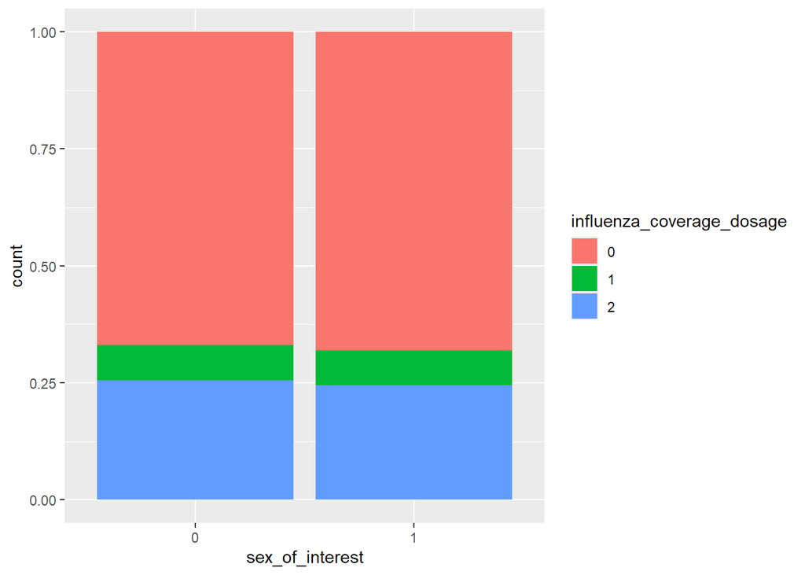

```r
inf_ivd |>
  filter(!is.na(influenza_coverage_dosage)) |>
  summarise(count = n(), .by = c(influenza_coverage_dosage, sex_of_interest)) |>

  ggplot() +
  geom_col(aes(x = sex_of_interest, y = count, fill = influenza_coverage_dosage), position = "fill")
```

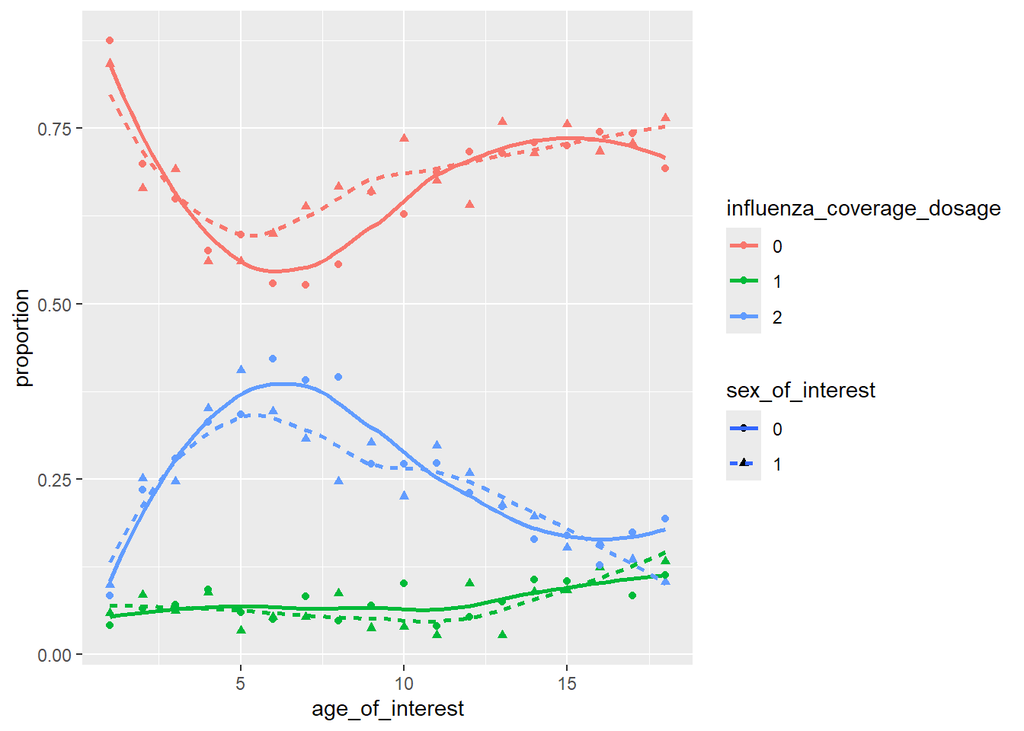

```r
inf_ivd |>
  filter(!is.na(influenza_coverage_dosage)) |>
  mutate(age_of_interest = round(age_of_interest)) |>
  summarise(count = n(), .by = c(influenza_coverage_dosage, sex_of_interest, age_of_interest)) |>
  mutate(proportion = count/sum(count), .by = c(age_of_interest, sex_of_interest)) -> inf_sex_age_dosage

inf_sex_age_dosage |>
  ggplot() +
  geom_point(aes(x = age_of_interest, y = proportion, shape = sex_of_interest, colour = influenza_coverage_dosage)) +
  geom_smooth(aes(x = age_of_interest, y = proportion, linetype = sex_of_interest, colour = influenza_coverage_dosage), se = FALSE)
```

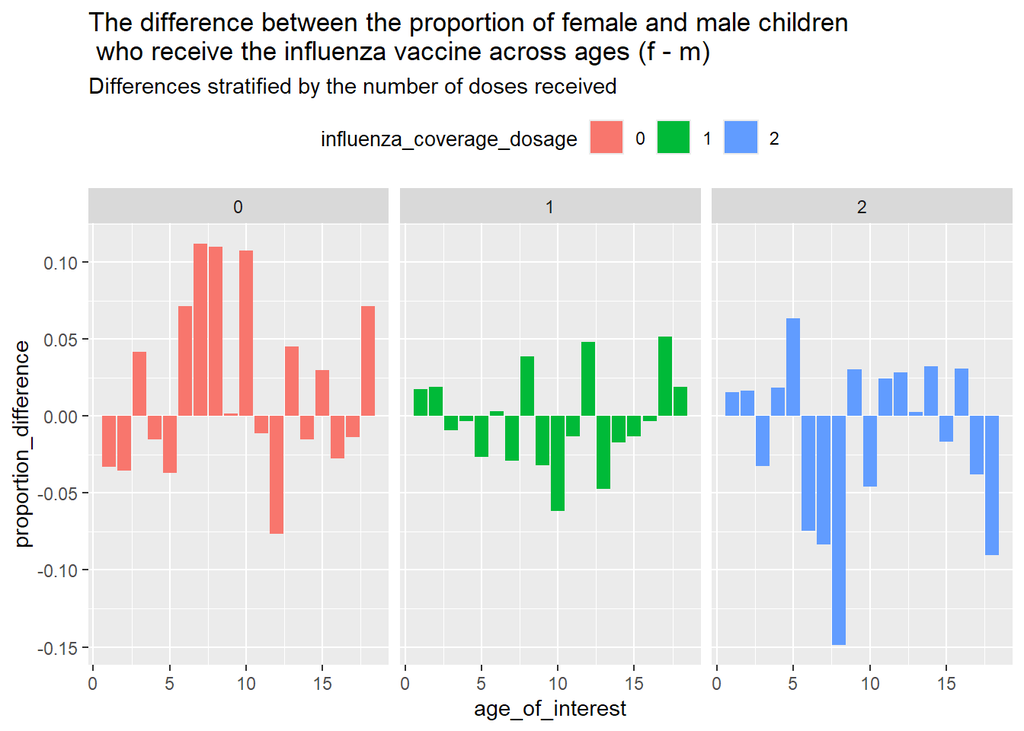

```r
inf_sex_age_dosage |>
  select(-count) |>
  pivot_wider(names_from = sex_of_interest, values_from = proportion) |>
  rename(male = `0`, female = `1`) |>
  mutate(proportion_difference = female - male) |>
  arrange(age_of_interest, influenza_coverage_dosage) |>
  ggplot() +
  geom_col(aes(x = age_of_interest, y = proportion_difference, fill = influenza_coverage_dosage)) +
  facet_wrap(vars(influenza_coverage_dosage)) +
  ggtitle("The difference between the proportion of female and male children \n who receive the influenza vaccine across ages (f - m)", "Differences stratified by the number of doses received") +
  theme(legend.position = "top", legend.title = element_text(size = 10))
```

What could account for the increase in proportion of female children (aged 6-10) who received 0 doses of the influenza vaccine? And subsequently, lack of females aged 6 to 8, who received 2 doses of the influenza vaccine

### Number of parents

Here is a breakdown of the number of children by the number of parents they have

```r
cov_ivd |>
  filter(!is.na(covid_coverage_age)) |>
  summarise(count = n(), .by = child_parents)
```

```
  child_parents count
1             2  5174
2             1   284
```

*Does the marital status of the parents and the number of parents a child has affect:* **1. The child’s covid vaccination status**

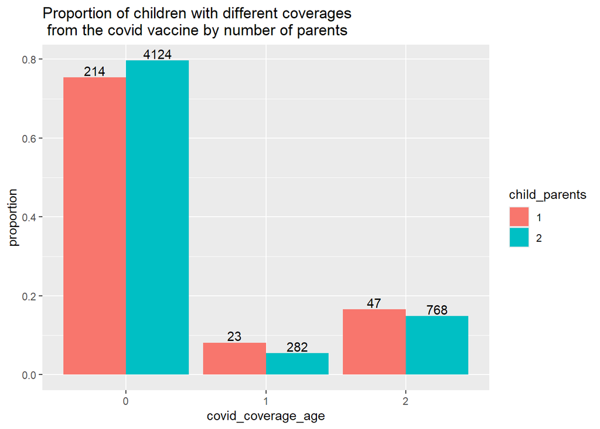

```r
cov_ivd |>
  filter(!is.na(covid_coverage_age)) |>
  summarise(count = n(), .by = c(child_parents, covid_coverage_age)) |>
  mutate(proportion = count/sum(count), .by = child_parents) |>
  mutate(child_parents = factor(child_parents)) |>

  ggplot(aes(x = covid_coverage_age, y = proportion)) +
  geom_col(aes(fill = child_parents), position = "dodge") +
  geom_text(aes(label = count, group = child_parents), position = position_dodge(width = 0.9), vjust = - 0.2) +
  labs(
    title = "Proportion of children with different coverages \n from the covid vaccine by number of parents"
  )
```

*2. the number of doses of the covid vaccine the child receives:*

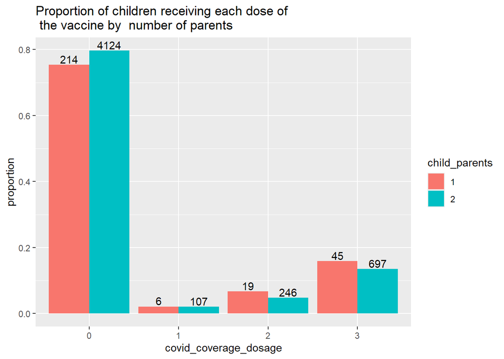

```r
cov_ivd |>
  filter(!is.na(covid_coverage_dosage)) |>
  summarise(count = n(), .by = c(child_parents, covid_coverage_dosage)) |>
  mutate(proportion = count/sum(count), .by = child_parents) |>
  mutate(child_parents = factor(child_parents)) |>

  ggplot(aes(x = covid_coverage_dosage, y = proportion)) +
  geom_col(aes(fill = child_parents), position = "dodge") +
  geom_text(aes(label = count, group = child_parents), position = position_dodge(width = 0.9), vjust = - 0.2) +
  labs(
    title = "Proportion of children receiving each dose of \n the vaccine by  number of parents"
  )
```

*3. the child’s (influenza) vaccination status:*

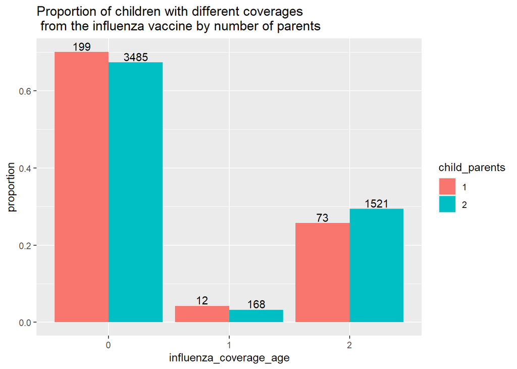

```r
inf_ivd |>
  filter(!is.na(influenza_coverage_age)) |>
  summarise(count = n(), .by = c(child_parents, influenza_coverage_age)) |>
  mutate(proportion = count/sum(count), .by = child_parents) |>
  mutate(child_parents = factor(child_parents)) |>

  ggplot(aes(x = influenza_coverage_age, y = proportion)) +
  geom_col(aes(fill = child_parents), position = "dodge") +
  geom_text(aes(label = count, group = child_parents), position = position_dodge(width = 0.9), vjust = - 0.2) +
  labs(
    title = "Proportion of children with different coverages \n from the influenza vaccine by number of parents"
  )
```

*the number of doses of the influenza vaccine the child receives*

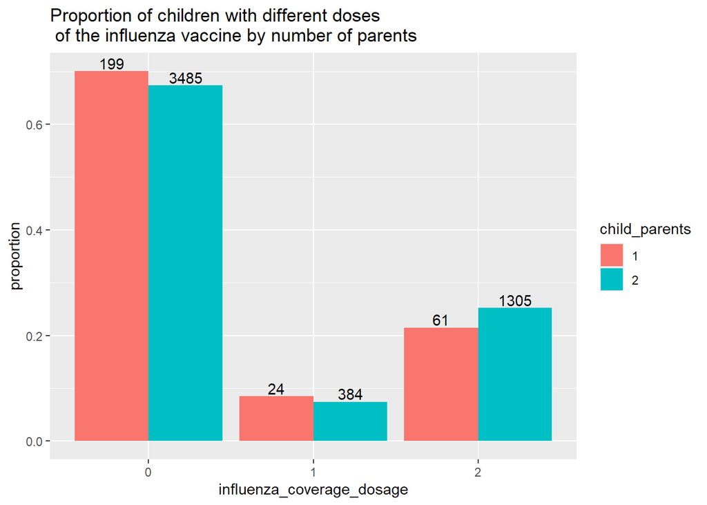

```r
inf_ivd |>
  filter(!is.na(influenza_coverage_dosage)) |>
  summarise(count = n(), .by = c(child_parents, influenza_coverage_dosage)) |>
  mutate(proportion = count/sum(count), .by = child_parents) |>
  mutate(child_parents = factor(child_parents)) |>

  ggplot(aes(x = influenza_coverage_dosage, y = proportion)) +
  geom_col(aes(fill = child_parents), position = "dodge") +
  geom_text(aes(label = count, group = child_parents), position = position_dodge(width = 0.9), vjust = - 0.2) +
  labs(
    title = "Proportion of children with different doses \n of the influenza vaccine by number of parents"
  )
```

In general, children from single parent families exhibit a higher uptake of the covid-19 vaccine than children with 2 parents.

conversley, children from sinle parent families have a lower tendency to obtain full coverage of the influenza vaccine (or 2 doses though this could be due to age) as compared to children with 2 parents

### Parent’s marital status

Here is a distribution of the number of children with parents of different marital statuses

```r
cov_ivd |>
  filter(!is.na(covid_coverage_dosage)) |>
  summarise(count = n(), .by = parents_marital_status)
```

```
  parents_marital_status count
1                      0  5217
2                      2   173
3                      3    57
4                      1    11
```

*Examining how a parent’s marital status affects their child’s uptake of the:* *Covid vaccine*

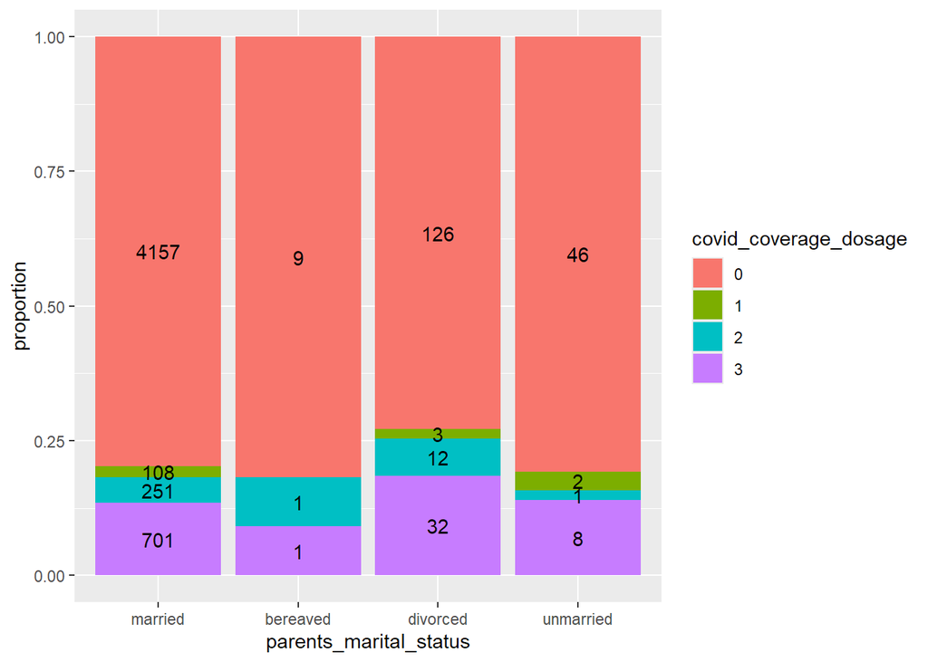

```r
cov_ivd |>
  filter(!is.na(covid_coverage_dosage)) |>
  summarise(count = n(), .by = c(parents_marital_status, covid_coverage_dosage)) |>
  mutate(proportion = count/sum(count), .by = parents_marital_status) |>

  ggplot(aes(x = parents_marital_status, y = proportion)) +
  geom_col(aes(fill = covid_coverage_dosage), position = "fill") +
  geom_text(aes(label = count, group = covid_coverage_dosage), position = position_fill(vjust = 0.5)) +
  scale_x_discrete(labels = c("married", "bereaved", "divorced", "unmarried"))
```

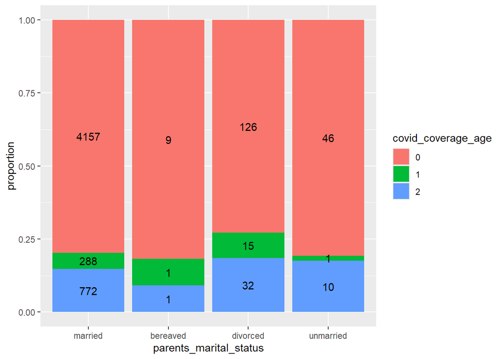

```r
cov_ivd |>
  filter(!is.na(covid_coverage_age)) |>
  summarise(count = n(), .by = c(parents_marital_status, covid_coverage_age)) |>
  mutate(proportion = count/sum(count), .by = parents_marital_status) |>

  ggplot(aes(x = parents_marital_status, y = proportion)) +
  geom_col(aes(fill = covid_coverage_age), position = "fill") +
  geom_text(aes(label = count, group = covid_coverage_age), position = position_fill(vjust = 0.5)) +
  scale_x_discrete(labels = c("married", "bereaved", "divorced", "unmarried"))
```

*the uptake of the influenza vaccine*

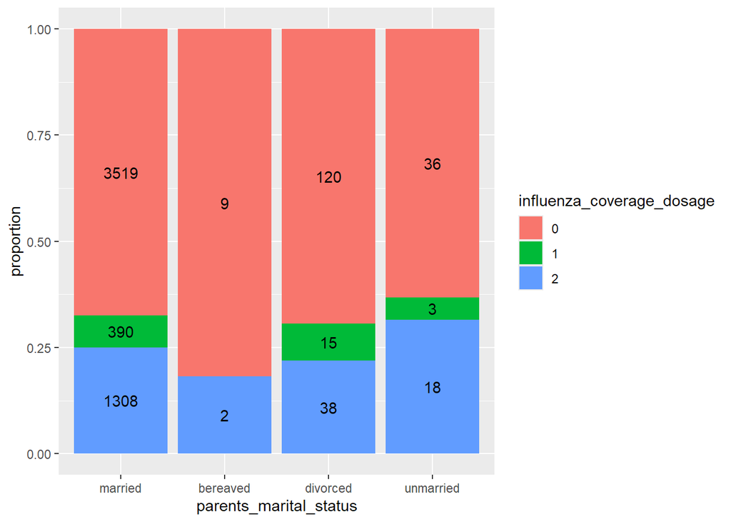

```r
inf_ivd |>
  filter(!is.na(influenza_coverage_dosage)) |>
  summarise(count = n(), .by = c(parents_marital_status, influenza_coverage_dosage)) |>
  mutate(proportion = count/sum(count), .by = parents_marital_status) |>

  ggplot(aes(x = parents_marital_status, y = proportion)) +
  geom_col(aes(fill = influenza_coverage_dosage), position = "fill") +
  geom_text(aes(label = count, group = influenza_coverage_dosage), position = position_fill(vjust = 0.5)) +
  scale_x_discrete(labels = c("married", "bereaved", "divorced", "unmarried"))
```

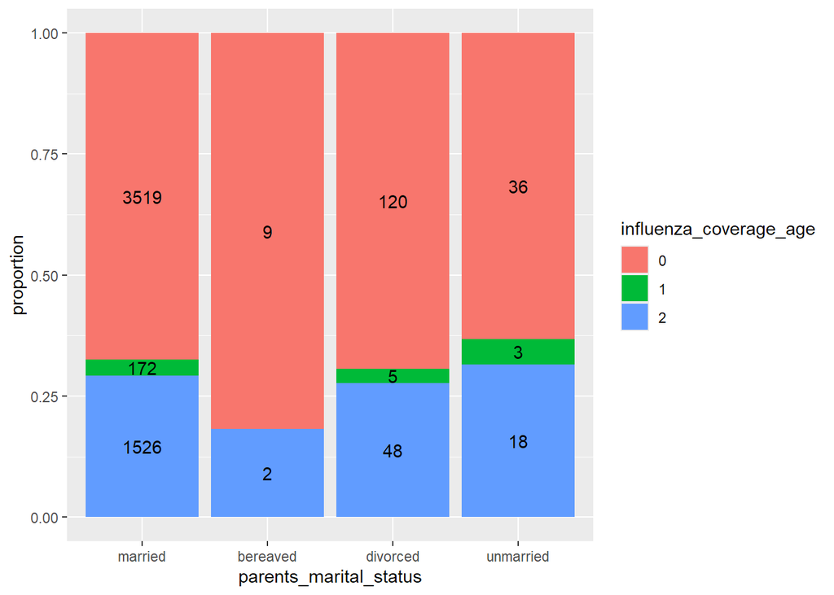

```r
inf_ivd |>
  filter(!is.na(influenza_coverage_age)) |>
  summarise(count = n(), .by = c(parents_marital_status, influenza_coverage_age)) |>
  mutate(proportion = count/sum(count), .by = parents_marital_status) |>

  ggplot(aes(x = parents_marital_status, y = proportion)) +
  geom_col(aes(fill = influenza_coverage_age), position = "fill") +
  geom_text(aes(label = count, group = influenza_coverage_age), position = position_fill(vjust = 0.5)) +
  scale_x_discrete(labels = c("married", "bereaved", "divorced", "unmarried"))
```

It seems that children of divorced parents have a much higher likelihood of obtaining full and partial coverage of the covid vaccine as compared to children of married parents but this doesn’t follow for influenza. Furthermore, children of parents who are unmarried (i.e. the child is adopted) show a much higher uptkae of the influenza vaccine though this could possibly be due to adoption requirements?

## Finances

### Annual household income

*Does the household’s annual income affect:* *the child’s uptake of the covid vaccine*

```r
# by doses
cov_ivd |>
  filter(!is.na(covid_coverage_dosage) & !is.na(household_income)) |>
  mutate(household_income = as.numeric(household_income)) |>
  summarise(count = n(), .by = c(household_income, covid_coverage_dosage)) |>
  mutate(proportion = count / sum(count), .by = household_income) -> covid_income_dosage

covid_income_dosage|>
  arrange(household_income, covid_coverage_dosage) |>
  select(-proportion) |>
  pivot_wider(names_from = covid_coverage_dosage, values_from = count)
```

```
# A tibble: 13 × 5
   household_income   `0`   `1`   `2`   `3`
              <dbl> <int> <int> <int> <int>
 1                1    27     1     1     2
 2                2    15     1     1     1
 3                3    19     2     1     1
 4                4    51    NA     2     4
 5                5   105     2     4    23
 6                6   275     4    13    31
 7                7   444     9    30    47
 8                8   539    12    28    84
 9                9   490    15    33    76
10               10   491    15    31    81
11               11   343     7    27    67
12               12   294     4    11    64
13               13   591    25    46   150
```

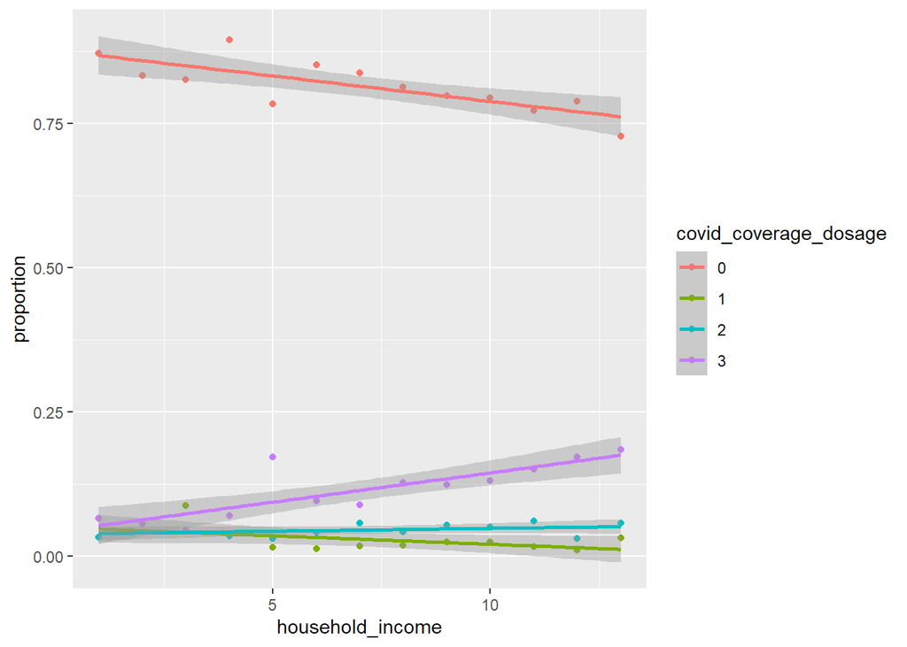

```r
# table showing the counts for each point on the plot (number of
# individuals who have each number of doses
covid_income_dosage |>
  ggplot(aes(x = household_income, y = proportion)) +
  geom_point(aes(colour = covid_coverage_dosage)) +
  geom_smooth(aes(colour = covid_coverage_dosage), method = "lm")
```

```r
# by degree of coverage
cov_ivd |>
  filter(!is.na(covid_coverage_age) & !is.na(household_income)) |>
  mutate(household_income = as.numeric(household_income)) |>
  summarise(count = n(), .by = c(household_income, covid_coverage_age)) |>
  mutate(proportion = count / sum(count), .by = household_income) -> covid_income_age

# table showing the counts for each point on the plot (number of
# individuals who fall into each coverage category
covid_income_age|>
  arrange(household_income, covid_coverage_age) |>
  select(-proportion) |>
  pivot_wider(names_from = covid_coverage_age, values_from = count)
```

```
# A tibble: 13 × 4
   household_income   `0`   `1`   `2`
              <dbl> <int> <int> <int>
 1                1    27     2     2
 2                2    15     2     1
 3                3    19     2     2
 4                4    51     2     4
 5                5   105     5    24
 6                6   275    12    36
 7                7   444    29    57
 8                8   539    30    94
 9                9   490    40    84
10               10   491    36    91
11               11   343    32    69
12               12   294    14    65
13               13   591    55   166
```

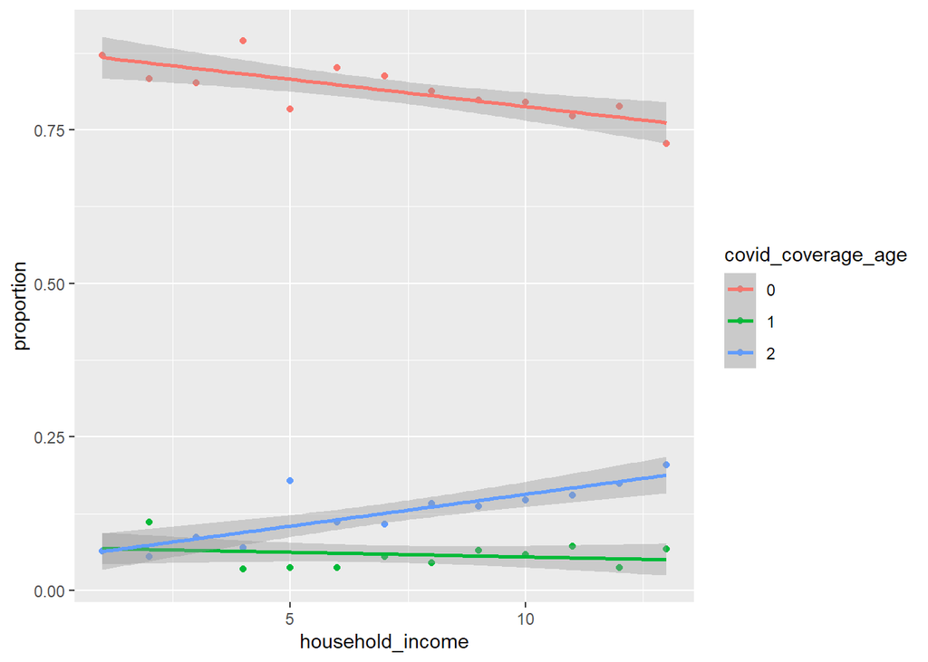

```r
# scatter plot
covid_income_age |>
  ggplot(aes(x = household_income, y = proportion)) +
  geom_point(aes(colour = covid_coverage_age)) +
  geom_smooth(aes(colour = covid_coverage_age), method = "lm")
```

*the child’s uptake of the influenza vaccine*

```r
# by number of doses
inf_ivd |>
  filter(!is.na(influenza_coverage_dosage) & !is.na(household_income)) |>
  summarise(count = n(), .by = c(household_income, influenza_coverage_dosage)) |>
  mutate(proportion = count / sum(count), .by = household_income) |>
  mutate(household_income = as.numeric(household_income)) -> influenza_income_dosage

# display a table showing the counts for each point on the plots
# the number of individuals for each number of doses
influenza_income_dosage |>
  arrange(household_income, influenza_coverage_dosage) |>
  select(-proportion) |>
  pivot_wider(names_from = influenza_coverage_dosage, values_from = count)
```

```
# A tibble: 13 × 4
   household_income   `0`   `2`   `1`
              <dbl> <int> <int> <int>
 1                1    26     5    NA
 2                2    14     3     1
 3                3    17     6    NA
 4                4    42    13     2
 5                5    90    32    12
 6                6   242    60    21
 7                7   376   123    31
 8                8   472   146    45
 9                9   409   154    51
10               10   417   158    43
11               11   289   118    37
12               12   250    98    25
13               13   486   240    86
```

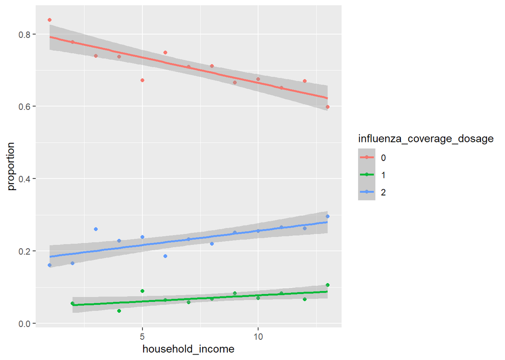

```r
# scatter plot
influenza_income_dosage |>
  ggplot(aes(x = household_income, y = proportion)) +
  geom_point(aes(colour = influenza_coverage_dosage)) +
  geom_smooth(aes(colour = influenza_coverage_dosage), method = "lm")
```

```r
# by degree of coverage
inf_ivd |>
  filter(!is.na(influenza_coverage_age) & !is.na(household_income)) |>
  summarise(count = n(), .by = c(household_income, influenza_coverage_age)) |>
  mutate(proportion = count / sum(count), .by = household_income) |>
  mutate(household_income = as.numeric(household_income))-> influenza_income_age

# display a table showing the counts for each point on the plots
# the number of individuals for each coverage status
influenza_income_age |>
  arrange(household_income, influenza_coverage_age) |>
  select(-proportion) |>
  pivot_wider(names_from = influenza_coverage_age, values_from = count)
```

```
# A tibble: 13 × 4
   household_income   `0`   `2`   `1`
              <dbl> <int> <int> <int>
 1                1    26     5    NA
 2                2    14     3     1
 3                3    17     6    NA
 4                4    42    14     1
 5                5    90    40     4
 6                6   242    72     9
 7                7   376   142    12
 8                8   472   169    22
 9                9   409   178    27
10               10   417   182    19
11               11   289   137    18
12               12   250   111    12
13               13   486   293    33
```

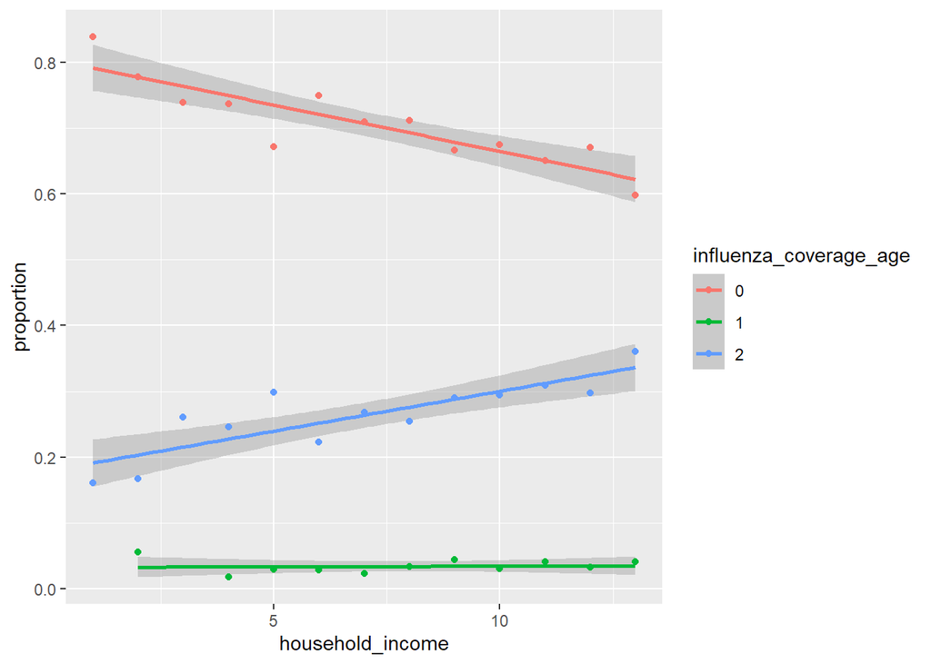

```r
# scatter plot
influenza_income_age |>
  ggplot(aes(x = household_income, y = proportion)) +
  geom_smooth(aes(colour = influenza_coverage_age), method = "lm") +
  geom_point(aes(colour = influenza_coverage_age))
```

Is there a threshold at category 3 (500 to 1000 * 100,000 yen a year) where they start receiving financial aid, and a threshold at category 6 (3000 to 4000 * 100,000 yen a year) where they stop receiving financial aid? this would explain the drop in influenza coverage as families no longer have subsidies to get their children vaccinated

## Chronic illness

The following is a breakdown of the number of children by their responding parent’s chronic illness status

```r
cov_ivd |>
  filter(!is.na(covid_coverage_dosage) & !is.na(parent_chronic_illness)) |>
  summarise(count = n(), .by = parent_chronic_illness)
```

```
  parent_chronic_illness count
1                      2  4009
2                      0   643
3                      1   806
```

*Examining if the presence of a chronic illness in the responding parent affects* *The child’s uptake of the covid vaccine*

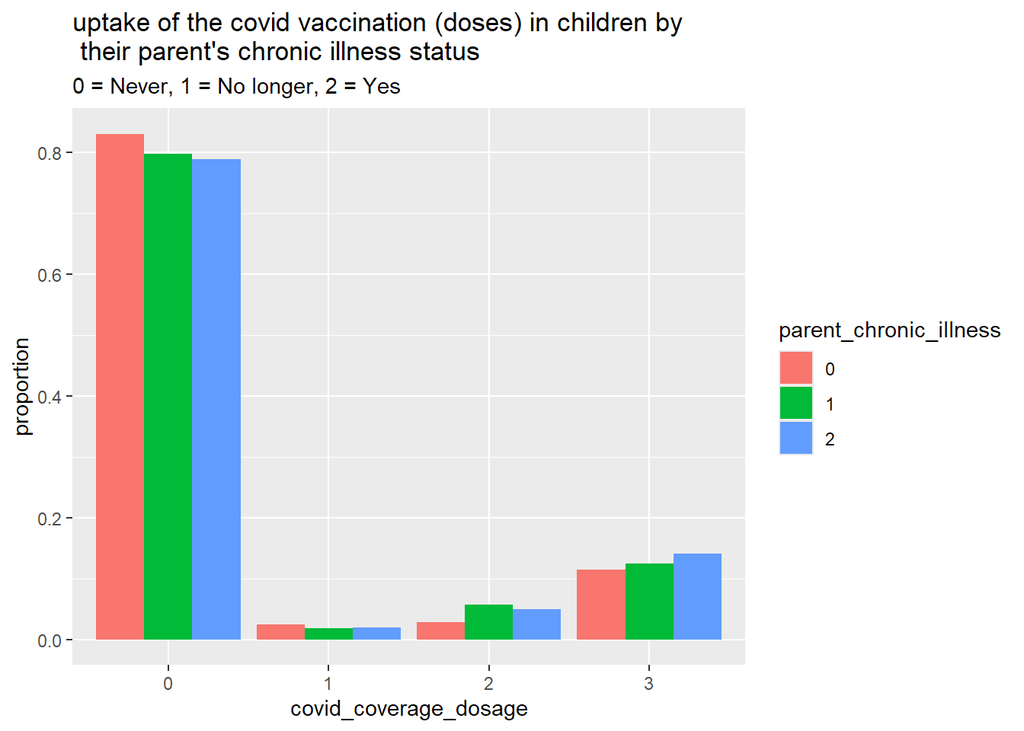

```r
cov_ivd |>
  filter(!is.na(covid_coverage_dosage) & !is.na(parent_chronic_illness)) |>
  summarise(count = n(), .by = c(covid_coverage_dosage, parent_chronic_illness)) |>
  mutate(proportion = count/sum(count), .by = parent_chronic_illness) |>

  ggplot(aes(x = covid_coverage_dosage, y = proportion)) +
  geom_col(aes(fill = parent_chronic_illness), position = "dodge") +
  labs(title = "uptake of the covid vaccination (doses) in children by \n their parent's chronic illness status", subtitle = "0 = Never, 1 = No longer, 2 = Yes")
```

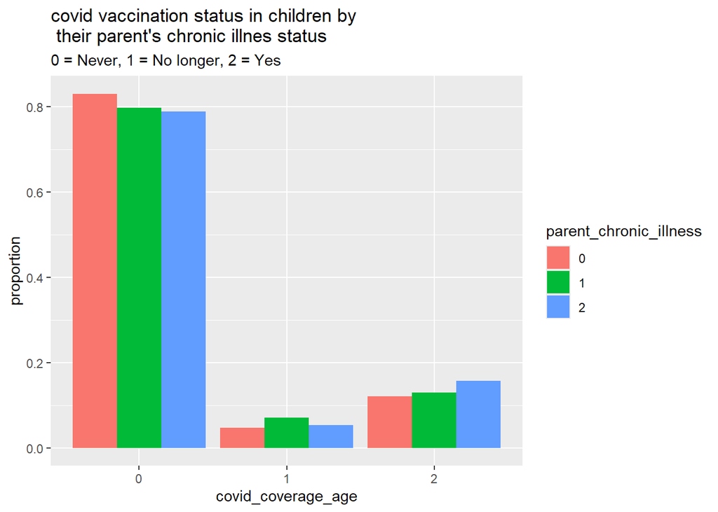

```r
cov_ivd |>
  filter(!is.na(covid_coverage_age) & !is.na(parent_chronic_illness)) |>
  summarise(count = n(), .by = c(covid_coverage_age, parent_chronic_illness)) |>
  mutate(proportion = count/sum(count), .by = parent_chronic_illness) |>

  ggplot(aes(x = covid_coverage_age, y = proportion)) +
  geom_col(aes(fill = parent_chronic_illness), position = "dodge") +
  labs(title = "covid vaccination status in children by \n their parent's chronic illnes status", subtitle = "0 = Never, 1 = No longer, 2 = Yes")
```

Though I don’t get if there’s any significance in this data given it’s only for your responding parent so there’s an equal chance of the othe parent having a chronic illness too?

Children of parent’s who have had or currently have a chronic illness exhibit higher coverages with the covid vaccine: - Children who have parent’s who used to have a chronic illness exhibit a higher uptake of partial covid vaccination - Children who have parent’s who currently have a chronic illness exhibit the highest uptake of full covid vaccination, closely followed by children whose responding parents used to have a chronic illness

*The child’s uptake of the influenza vaccine*

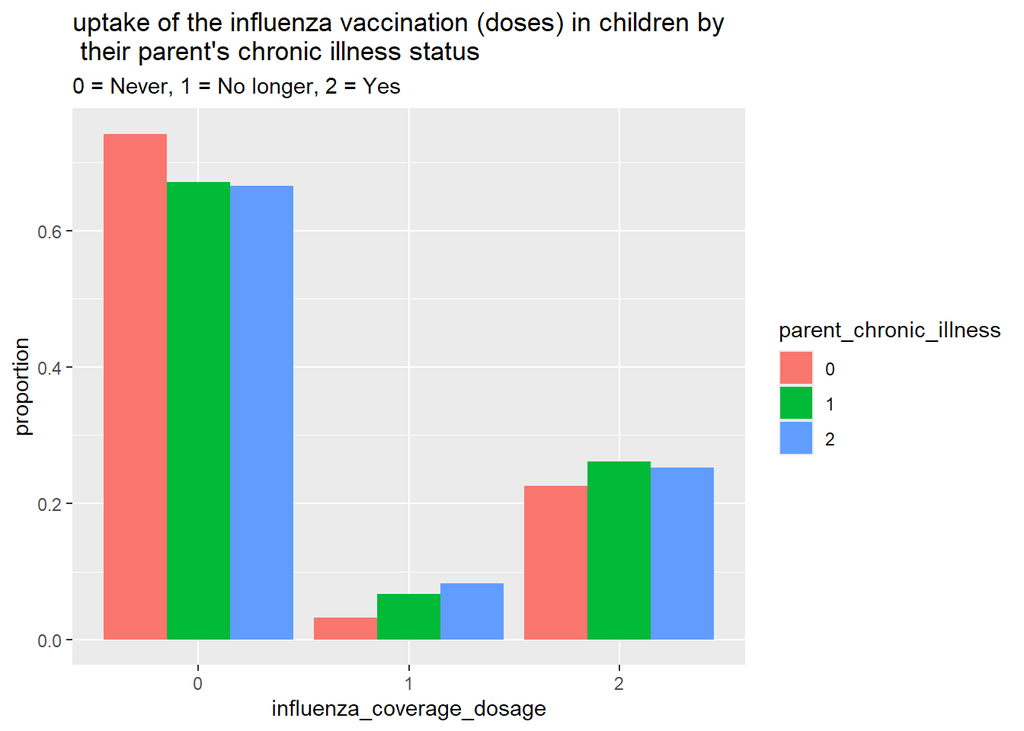

```r
inf_ivd |>
  filter(!is.na(influenza_coverage_dosage) & !is.na(parent_chronic_illness)) |>
  summarise(count = n(), .by = c(influenza_coverage_dosage, parent_chronic_illness)) |>
  mutate(proportion = count/sum(count), .by = parent_chronic_illness) |>

  ggplot(aes(x = influenza_coverage_dosage, y = proportion)) +
  geom_col(aes(fill = parent_chronic_illness), position = "dodge") +
  labs(title = "uptake of the influenza vaccination (doses) in children by \n their parent's chronic illness status", subtitle = "0 = Never, 1 = No longer, 2 = Yes")
```

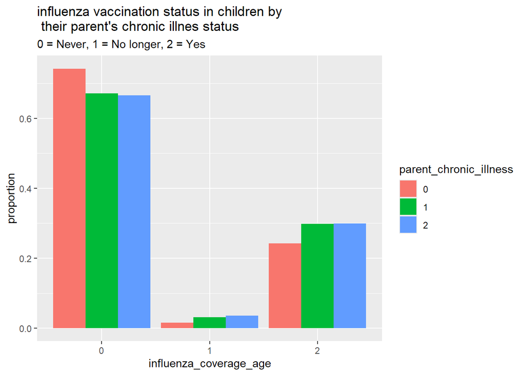

```r
inf_ivd |>
  filter(!is.na(influenza_coverage_age) & !is.na(parent_chronic_illness)) |>
  summarise(count = n(), .by = c(influenza_coverage_age, parent_chronic_illness)) |>
  mutate(proportion = count/sum(count), .by = parent_chronic_illness) |>

  ggplot(aes(x = influenza_coverage_age, y = proportion)) +
  geom_col(aes(fill = parent_chronic_illness), position = "dodge") +
  labs(title = "influenza vaccination status in children by \n their parent's chronic illnes status", subtitle = "0 = Never, 1 = No longer, 2 = Yes")
```

**Looking at children with only 1 parent, to ensure we ignore effects of the other parent**

```r
cov_ivd |>

  filter(child_parents == 1 & !is.na(covid_coverage_age) & !is.na(parent_chronic_illness)) |>
  summarise(count = n(), .by = parent_chronic_illness)
```

```
  parent_chronic_illness count
1                      2   232
2                      0    22
3                      1    30
```

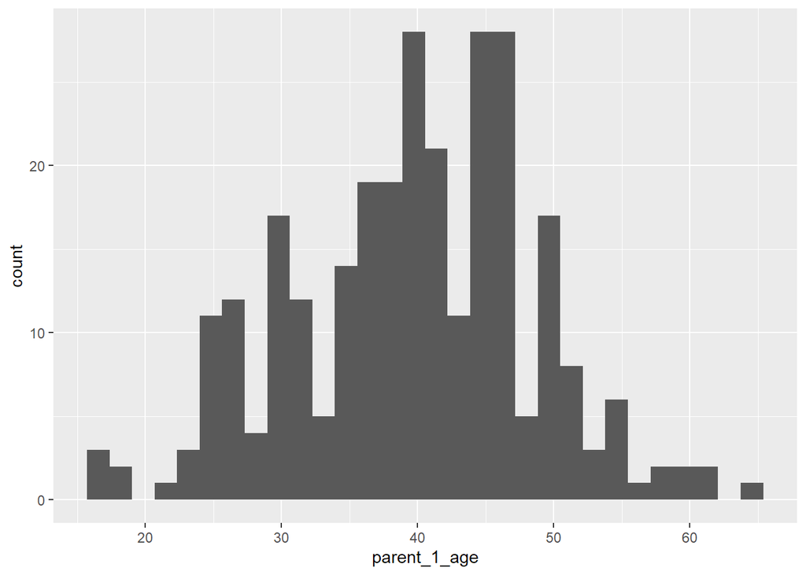

```r
cov_ivd |>
  filter(child_parents == 1 & !is.na(parent_chronic_illness))|>
  ggplot() +
  geom_histogram(aes(parent_1_age))
```

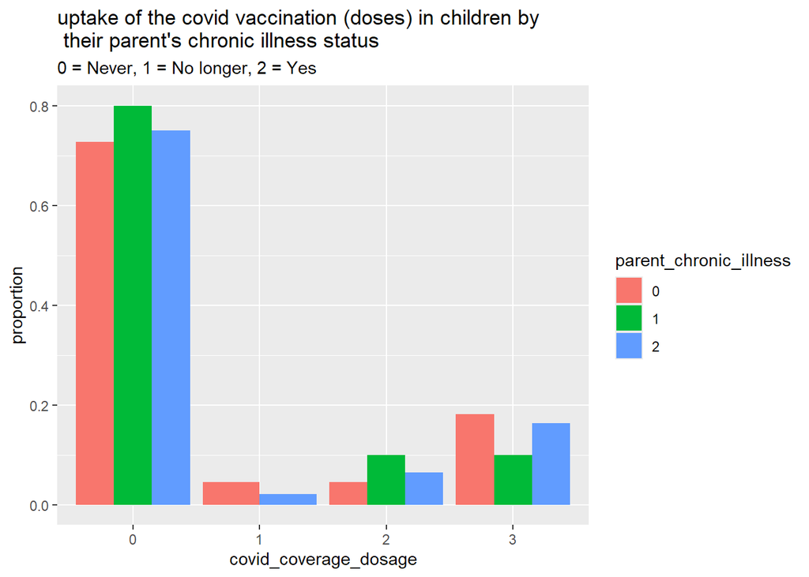

```r
cov_ivd |>
  filter(!is.na(covid_coverage_dosage) & child_parents == 1 & !is.na(parent_chronic_illness)) |>
  summarise(count = n(), .by = c(covid_coverage_dosage, parent_chronic_illness)) |>
  mutate(proportion = count/sum(count), .by = parent_chronic_illness) |>

  ggplot(aes(x = covid_coverage_dosage, y = proportion)) +
  geom_col(aes(fill = parent_chronic_illness), position = "dodge") +
  labs(title = "uptake of the covid vaccination (doses) in children by \n their parent's chronic illness status", subtitle = "0 = Never, 1 = No longer, 2 = Yes")
```

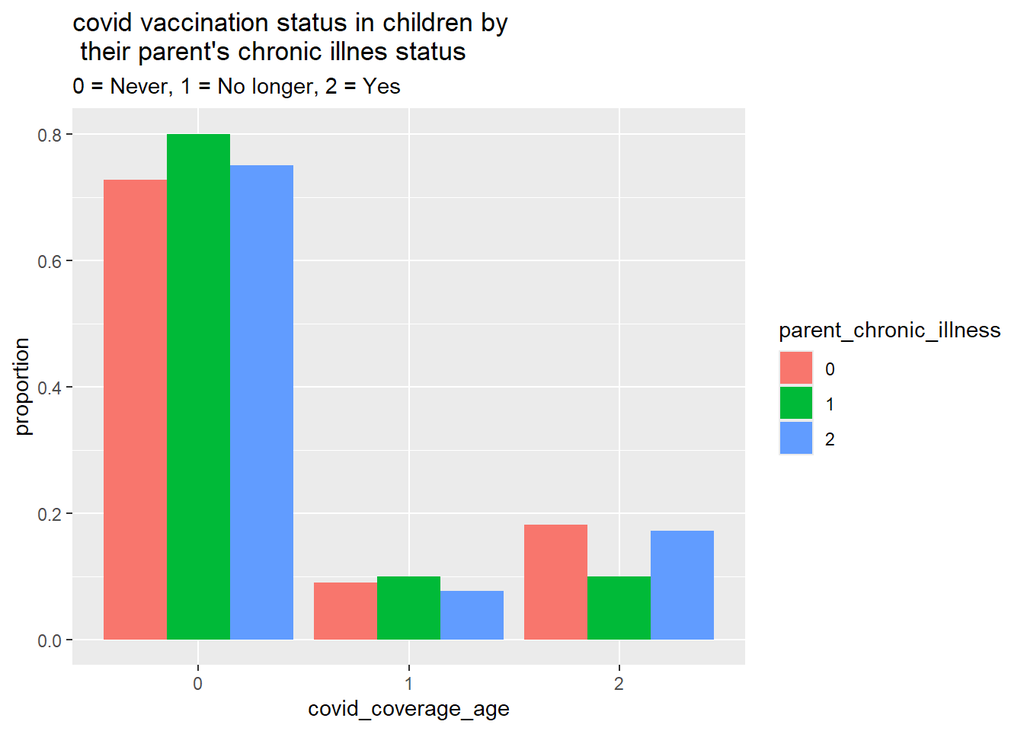

```r
cov_ivd |>
  filter(!is.na(covid_coverage_age) & child_parents == 1 & !is.na(parent_chronic_illness)) |>
  summarise(count = n(), .by = c(covid_coverage_age, parent_chronic_illness)) |>
  mutate(proportion = count/sum(count), .by = parent_chronic_illness) |>

  ggplot(aes(x = covid_coverage_age, y = proportion)) +
  geom_col(aes(fill = parent_chronic_illness), position = "dodge") +
  labs(title = "covid vaccination status in children by \n their parent's chronic illnes status", subtitle = "0 = Never, 1 = No longer, 2 = Yes")
```

For the covid vaccine, having a parent who USED to have a chronic illness was not a strong indicator of full covid coverage (for single-parent children) as opposed to it being a strong indicator of full covid coverage (for dual-parent children)

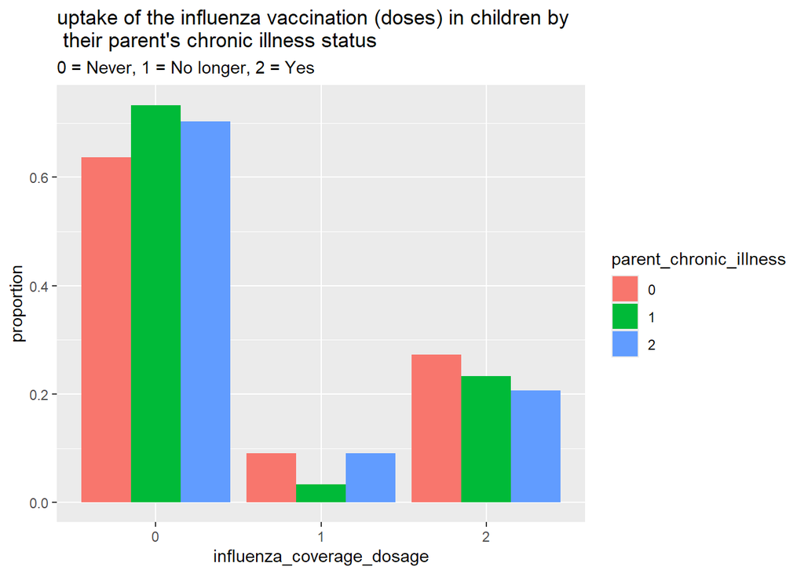

```r
inf_ivd |>
  filter(!is.na(influenza_coverage_dosage) & child_parents == 1 & !is.na(parent_chronic_illness)) |>
  summarise(count = n(), .by = c(influenza_coverage_dosage, parent_chronic_illness)) |>
  mutate(proportion = count/sum(count), .by = parent_chronic_illness) |>

  ggplot(aes(x = influenza_coverage_dosage, y = proportion)) +
  geom_col(aes(fill = parent_chronic_illness), position = "dodge") +
  labs(title = "uptake of the influenza vaccination (doses) in children by \n their parent's chronic illness status", subtitle = "0 = Never, 1 = No longer, 2 = Yes")
```

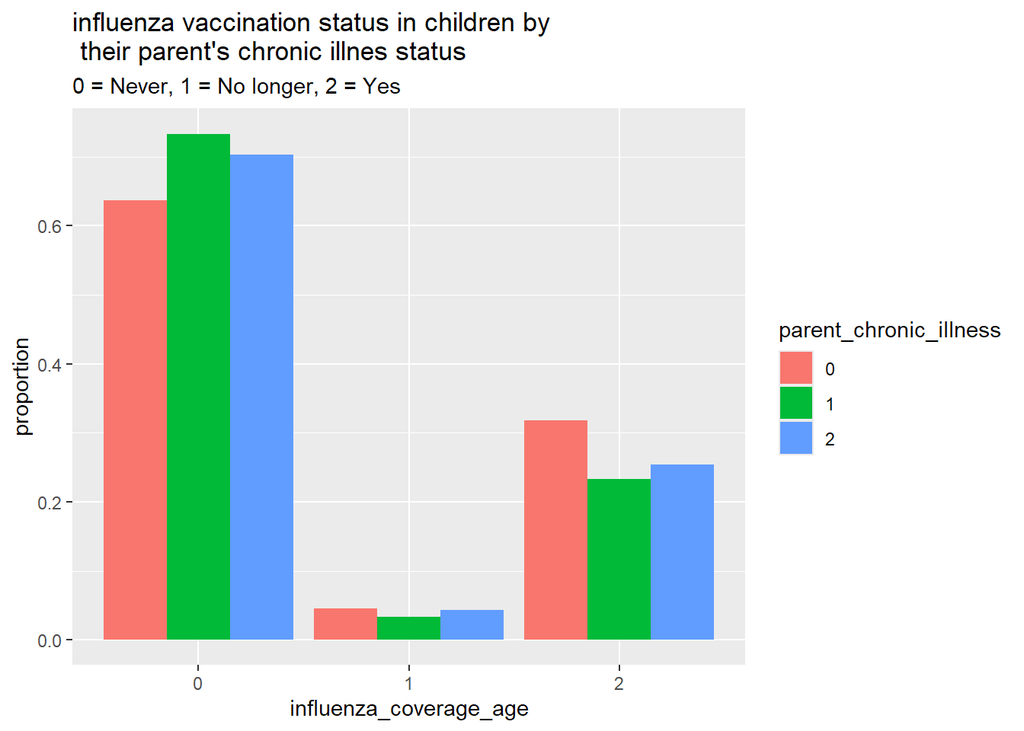

```r
inf_ivd |>
  filter(!is.na(influenza_coverage_age) & child_parents == 1 & !is.na(parent_chronic_illness)) |>
  summarise(count = n(), .by = c(influenza_coverage_age, parent_chronic_illness)) |>
  mutate(proportion = count/sum(count), .by = parent_chronic_illness) |>

  ggplot(aes(x = influenza_coverage_age, y = proportion)) +
  geom_col(aes(fill = parent_chronic_illness), position = "dodge") +
  labs(title = "influenza vaccination status in children by \n their parent's chronic illnes status", subtitle = "0 = Never, 1 = No longer, 2 = Yes")
```

As is the same for influenza, children whose parents USED TO have a chronic illness did not exhibit a higher uptake of the influenza vaccine (for children with 1 parent) as opposed to children with 2 parents.

Furthermore, parents not having a chronic illness is now positively associated with children having full coverage with the influenza vaccine (for children with 1 parent) as opposed to it not being a positive predictor (for children with 2 parents) of the influenza vaccine.

## Industry of work

### Respondent parent working in healthcare

*Does the industry of work of the child’s respondent parent affect the child’s uptake of* *The covid vaccnine*

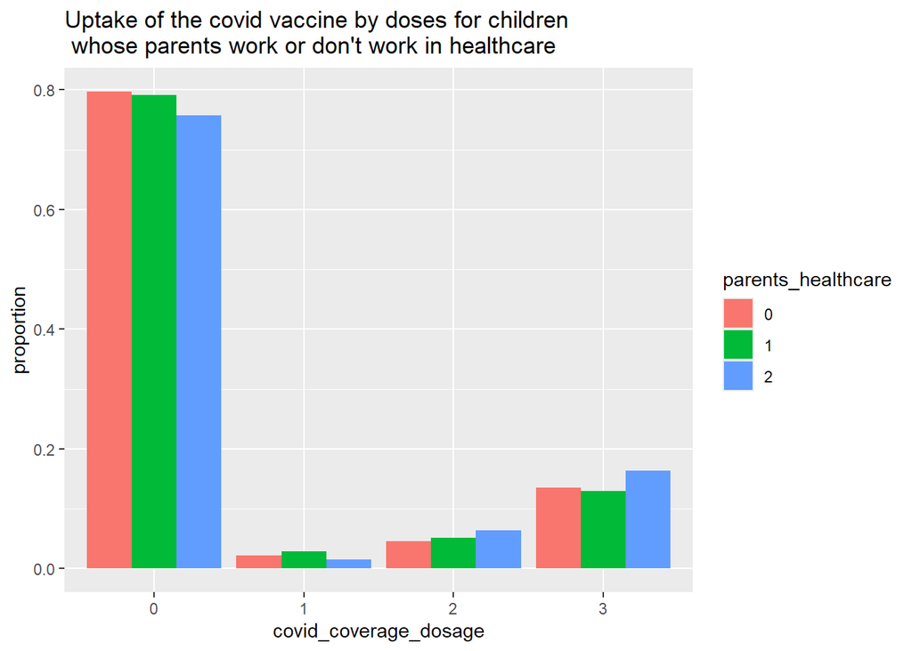

```r
cov_ivd |>
  filter(!is.na(covid_coverage_dosage) & !is.na(parents_healthcare)) |>
  summarise(count = n(), .by = c(covid_coverage_dosage, parents_healthcare)) |>
  mutate(proportion = count/sum(count), .by = parents_healthcare) |>

  ggplot(aes(x = covid_coverage_dosage, y = proportion)) +
  geom_col(aes(fill = parents_healthcare), position = "dodge") +
  labs(title = "Uptake of the covid vaccine by doses for children \n whose parents work or don't work in healthcare")
```

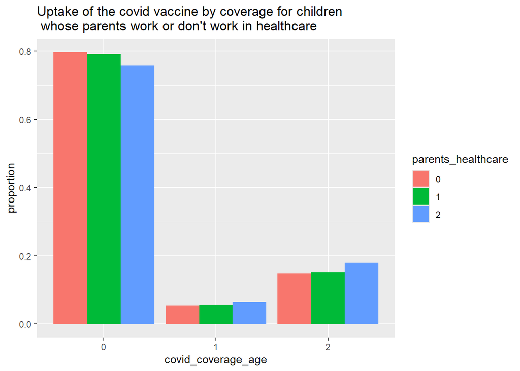

```r
cov_ivd |>
  filter(!is.na(covid_coverage_age) & !is.na(parents_healthcare)) |>
  summarise(count = n(), .by = c(covid_coverage_age, parents_healthcare)) |>
  mutate(proportion = count/sum(count), .by = parents_healthcare) |>

  ggplot(aes(x = covid_coverage_age, y = proportion)) +
  geom_col(aes(fill = parents_healthcare), position = "dodge") +
  labs(title = "Uptake of the covid vaccine by coverage for children \n whose parents work or don't work in healthcare")
```

*The influenza vaccine*

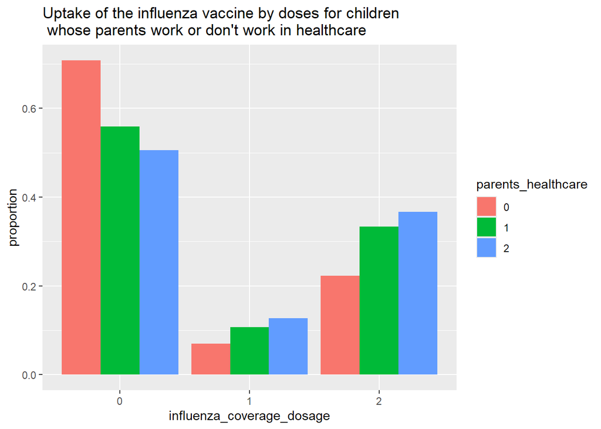

```r
inf_ivd |>
  filter(!is.na(influenza_coverage_dosage) & !is.na(parents_healthcare)) |>
  summarise(count = n(), .by = c(influenza_coverage_dosage, parents_healthcare)) |>
  mutate(proportion = count/sum(count), .by = parents_healthcare) |>

  ggplot(aes(x = influenza_coverage_dosage, y = proportion)) +
  geom_col(aes(fill = parents_healthcare), position = "dodge") +
  labs(title = "Uptake of the influenza vaccine by doses for children \n whose parents work or don't work in healthcare")
```

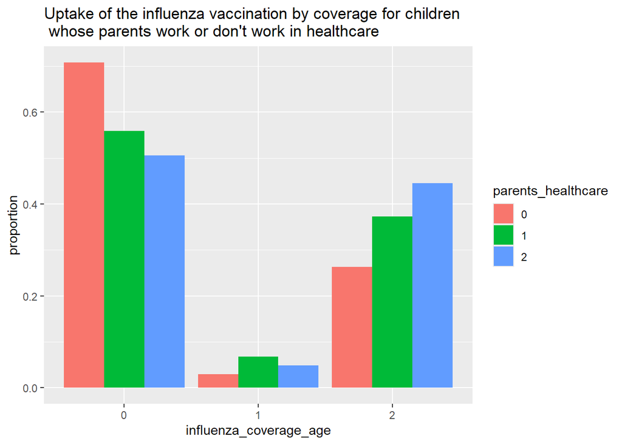

```r
inf_ivd |>
  filter(!is.na(influenza_coverage_age) & !is.na(parents_healthcare)) |>
  summarise(count = n(), .by = c(influenza_coverage_age, parents_healthcare)) |>
  mutate(proportion = count/sum(count), .by = parents_healthcare) |>

  ggplot(aes(x = influenza_coverage_age, y = proportion)) +
  geom_col(aes(fill = parents_healthcare), position = "dodge") +
  labs(title = "Uptake of the influenza vaccination by coverage for children \n whose parents work or don't work in healthcare")
```

## Parent’s highest educational attianment

### Parent’s highest education by qualification

The following is a breakdown of the highest education of mothers, fathers and those 2 combined of the children of interest

```r
ivd |>
  filter(child_of_interest == 1 & !is.na(mother_highest_education)) |>
  summarise(count = n(), .by = mother_highest_education) |>
  arrange(mother_highest_education)
```

```
  mother_highest_education count
1              Junior High    79
2                  Highsch  1001
3                 Tertiary  4347
4                 Postgrad   137
```

```r
ivd |>
  filter(child_of_interest == 1 & !is.na(father_highest_education)) |>
  summarise(count = n(), .by = father_highest_education) |>
  arrange(father_highest_education)
```

```
  father_highest_education count
1              Junior High   120
2                  Highsch  1037
3                 Tertiary  3726
4                 Postgrad   522
```

```r
ivd |>
  function_data_stratify(parents_highest_education, as.factor, parents_highest_education)
```

```
  parents_highest_education count proportion
1                  Tertiary  4914          1
2                   Highsch   475          1
3                  Postgrad   138          1
4               Junior High    96          1
```

*Does the highest educational qualification of a child’s parents affect:* *The child’s uptake of the covid vaccine*

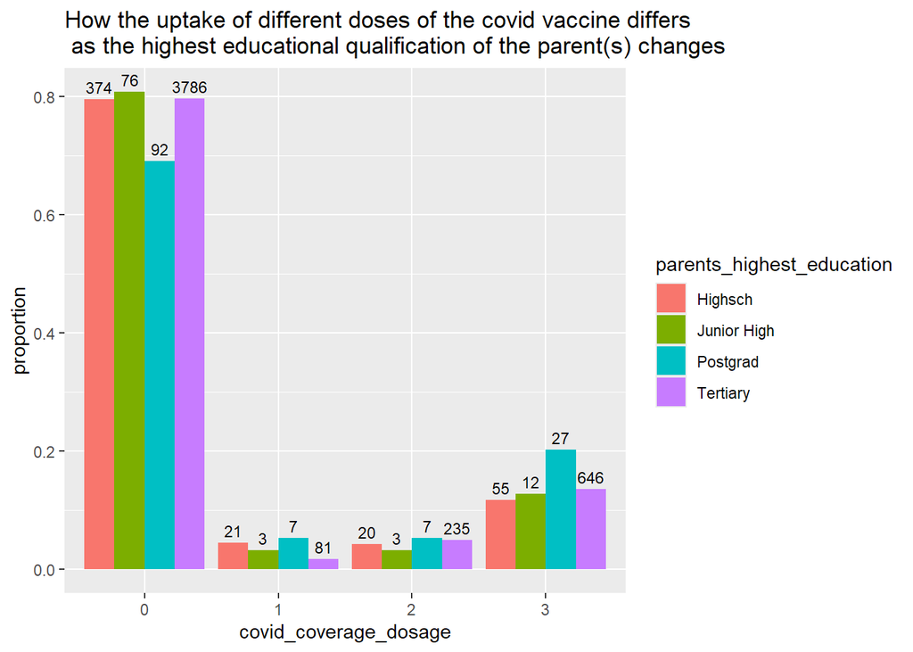

```r
# by the number of doses of the covid vaccine
cov_ivd |>
  filter(!is.na(parents_highest_education) & !is.na(covid_coverage_dosage)) |>
  summarise(count = n(), .by = c(parents_highest_education, covid_coverage_dosage)) |>
  mutate(proportion = count/sum(count), .by = parents_highest_education) |>
  mutate(parents_highest_education = factor(parents_highest_education)) |>

  ggplot() +
  geom_col(aes(x = covid_coverage_dosage, y = proportion, fill = parents_highest_education), position = "dodge") +
  geom_text(aes(x = covid_coverage_dosage, y = proportion, group = parents_highest_education, label = count), position = position_dodge(width = 0.9), size = 3, vjust = -0.5) +
  labs(
    title = "How the uptake of different doses of the covid vaccine differs \n as the highest educational qualification of the parent(s) changes",
    ) +

  #add legend
  scale_fill_discrete(
    labels = c("0" = "Junior High", "1" = "Highsch", "2" = "Tertiary", "3" = "Postgrad")
  )
```

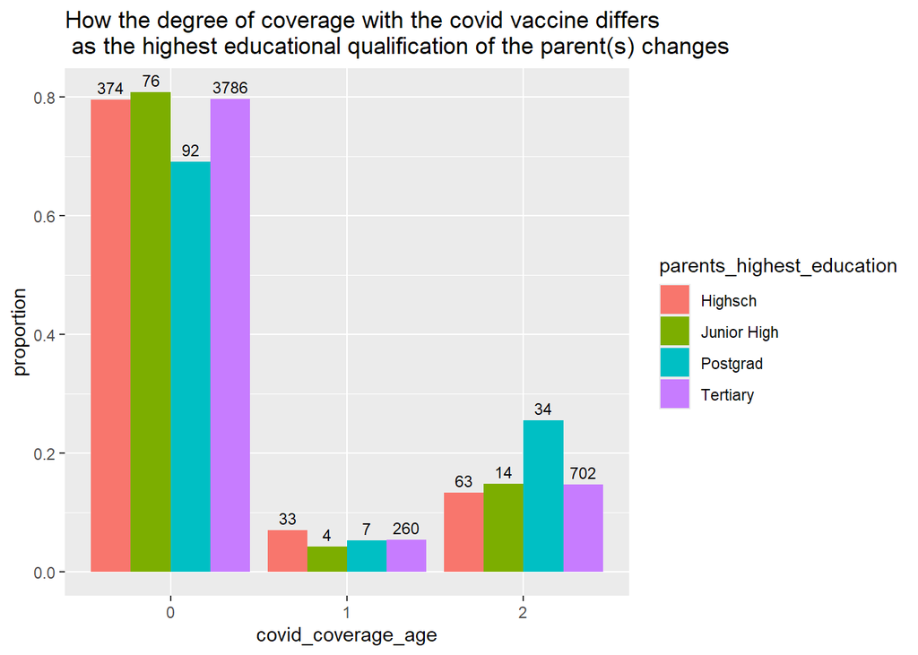

```r
# by the degree of coverage of the covid vaccine
cov_ivd |>
  filter(!is.na(parents_highest_education) & !is.na(covid_coverage_age)) |>
  summarise(count = n(), .by = c(parents_highest_education, covid_coverage_age)) |>
  mutate(proportion = count/sum(count), .by = parents_highest_education) |>
  mutate(parents_highest_education = factor(parents_highest_education)) |>

  ggplot() +
  geom_col(aes(x = covid_coverage_age, y = proportion, fill = parents_highest_education), position = "dodge") +
  geom_text(aes(x = covid_coverage_age, y = proportion, group = parents_highest_education, label = count), position = position_dodge(width = 0.9), size = 3, vjust = -0.5) +
  labs(
    title = "How the degree of coverage with the covid vaccine differs \n as the highest educational qualification of the parent(s) changes",
    ) +

  #add legend
  scale_fill_discrete(
    labels = c("0" = "Junior High", "1" = "Highsch", "2" = "Tertiary", "3" = "Postgrad")
  )
```

*The influenza vaccine*

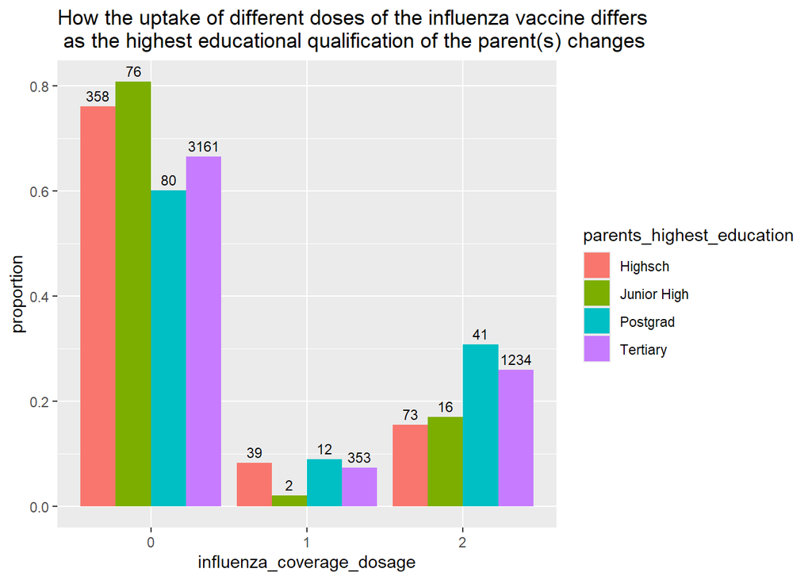

```r
# by the number of doses of the influenza vaccine
inf_ivd |>
  filter(!is.na(parents_highest_education) & !is.na(influenza_coverage_dosage)) |>
  summarise(count = n(), .by = c(parents_highest_education, influenza_coverage_dosage)) |>
  mutate(proportion = count/sum(count), .by = parents_highest_education) |>
  mutate(parents_highest_education = factor(parents_highest_education)) |>

  ggplot() +
  geom_col(aes(x = influenza_coverage_dosage, y = proportion, fill = parents_highest_education), position = "dodge") +
  geom_text(aes(x = influenza_coverage_dosage, y = proportion, group = parents_highest_education, label = count), position = position_dodge(width = 0.9), size = 3, vjust = -0.5) +
  labs(
    title = "How the uptake of different doses of the influenza vaccine differs \n as the highest educational qualification of the parent(s) changes",
    ) +

  #add legend
  scale_fill_discrete(
    labels = c("0" = "Junior High", "1" = "Highsch", "2" = "Tertiary", "3" = "Postgrad")
  )
```

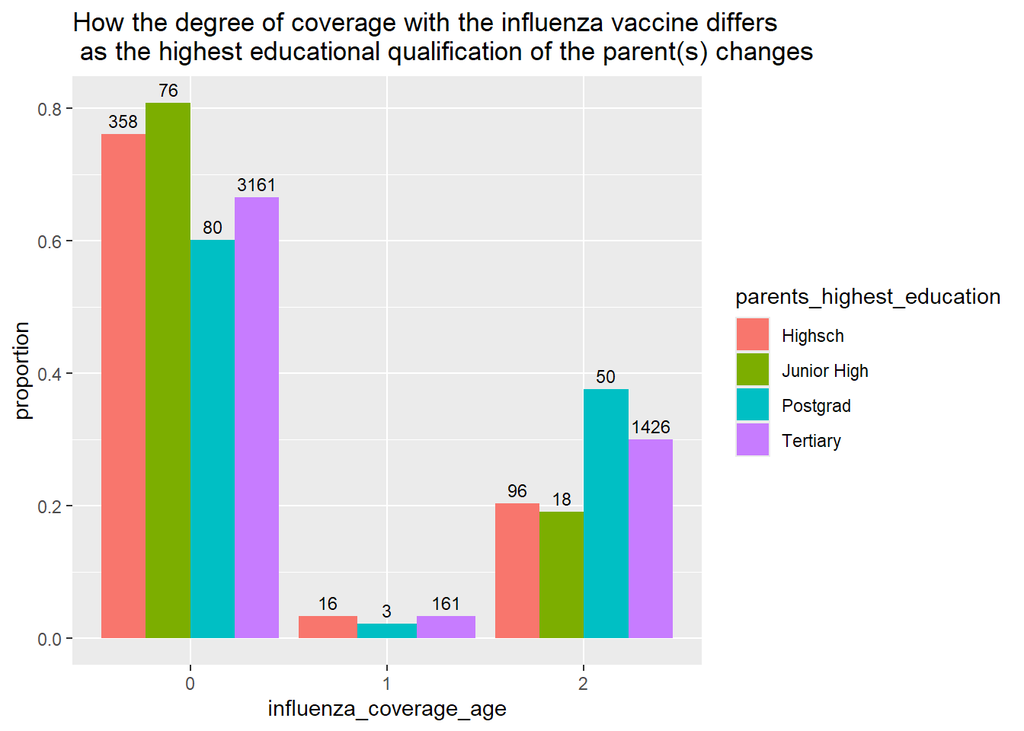

```r
# by the degree of coverage of the covid vaccine
inf_ivd |>
  filter(!is.na(parents_highest_education) & !is.na(influenza_coverage_age)) |>
  summarise(count = n(), .by = c(parents_highest_education, influenza_coverage_age)) |>
  mutate(proportion = count/sum(count), .by = parents_highest_education) |>
  mutate(parents_highest_education = factor(parents_highest_education)) |>

  ggplot() +
  geom_col(aes(x = influenza_coverage_age, y = proportion, fill = parents_highest_education), position = "dodge") +
  geom_text(aes(x = influenza_coverage_age, y = proportion, group = parents_highest_education, label = count), position = position_dodge(width = 0.9), size = 3, vjust = -0.5) +
  labs(
    title = "How the degree of coverage with the influenza vaccine differs \n as the highest educational qualification of the parent(s) changes",
    ) +

  #add legend
  scale_fill_discrete(
    labels = c("0" = "Junior High", "1" = "Highsch", "2" = "Tertiary", "3" = "Postgrad")
  )
```

The highest educational attainment of both parents being Tertiary or Postgraduate education are associated with a higher uptake of the influenza vaccines whilst th highest educational attainment being Tertiary doesn’t seem to be predictive of a higher uptake of the covid vaccination

*Does the highest educational attainment of the COI’s fatherand mother affect* *The child’s uptake of the covid vaccine*

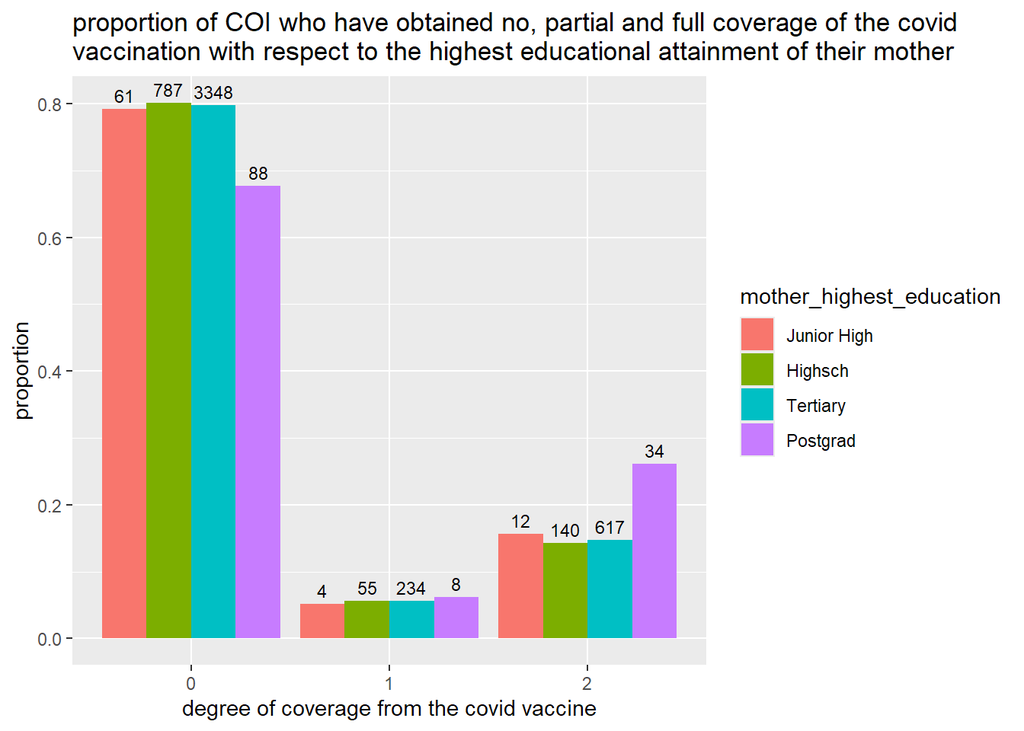

```r
# covid vaccine
# covid vax coverage with mothers' educational attainments
cov_ivd |>
  filter(!is.na(covid_coverage_age) & !is.na(mother_highest_education)) |>
  summarise(count = n(), .by = c(mother_highest_education, covid_coverage_age)) |>
  mutate(proportion = count/sum(count), .by = mother_highest_education) |>

  ggplot(aes(x = covid_coverage_age, y = proportion)) +
  geom_col(aes(fill = mother_highest_education), position = "dodge") +
  function_plot_label_count(mother_highest_education, coverage = covid_coverage_age) +
  labs(title = "proportion of COI who have obtained no, partial and full coverage of the covid\nvaccination with respect to the highest educational attainment of their mother") +
  xlab("degree of coverage from the covid vaccine")
```

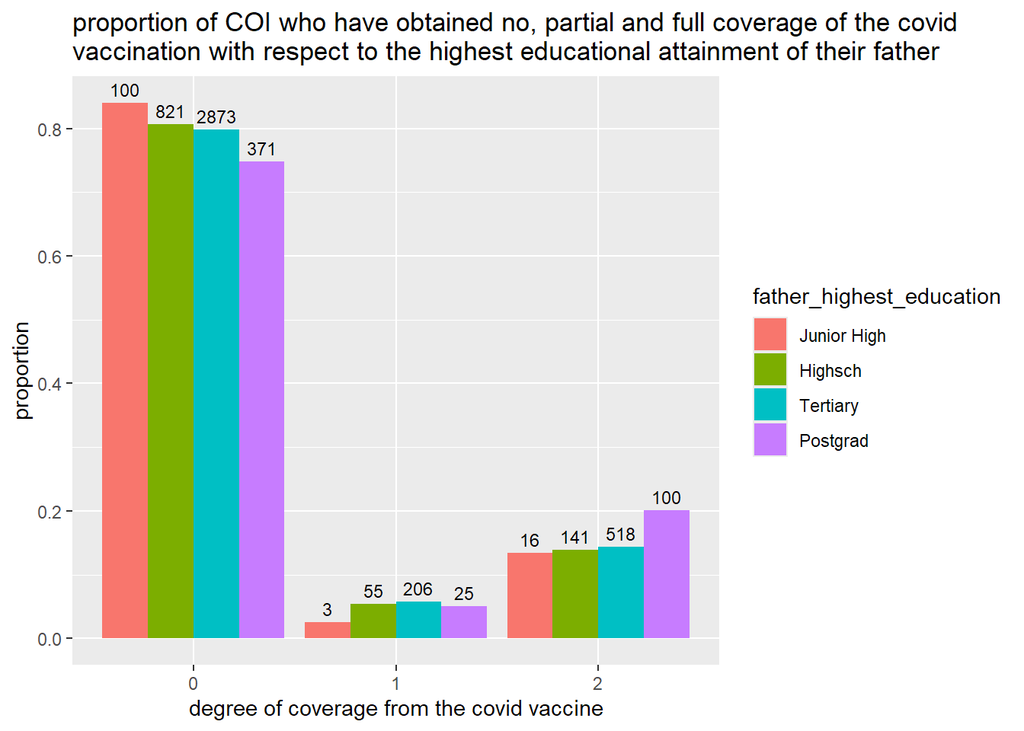

```r
# covid vax coverage with fathers' highest educational attainments
cov_ivd |>
  filter(!is.na(covid_coverage_age) & !is.na(father_highest_education)) |>
  summarise(count = n(), .by = c(father_highest_education, covid_coverage_age)) |>
  mutate(proportion = count/sum(count), .by = father_highest_education) |>

  ggplot(aes(x = covid_coverage_age, y = proportion)) +
  geom_col(aes(fill = father_highest_education), position = "dodge") +
  function_plot_label_count(father_highest_education, coverage = covid_coverage_age) +
  labs(title = "proportion of COI who have obtained no, partial and full coverage of the covid\nvaccination with respect to the highest educational attainment of their father") +
  xlab("degree of coverage from the covid vaccine")
```

*The influenza vaccine*

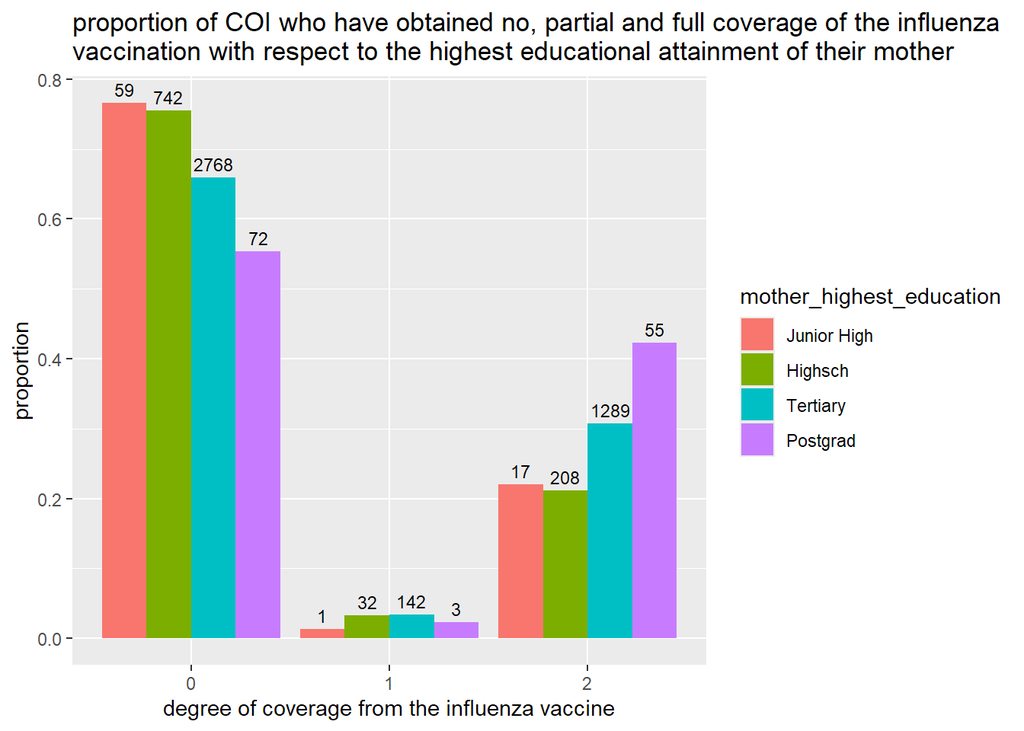

```r
# influenza vaccine
# covid vax coverage with mothers' educational attainments
inf_ivd |>
  filter(!is.na(influenza_coverage_age) & !is.na(mother_highest_education)) |>
  summarise(count = n(), .by = c(mother_highest_education, influenza_coverage_age)) |>
  mutate(proportion = count/sum(count), .by = mother_highest_education) |>

  ggplot(aes(x = influenza_coverage_age, y = proportion)) +
  geom_col(aes(fill = mother_highest_education), position = "dodge") +
  function_plot_label_count(mother_highest_education, influenza_coverage_age) +
  labs(title = "proportion of COI who have obtained no, partial and full coverage of the influenza\nvaccination with respect to the highest educational attainment of their mother") +
  xlab("degree of coverage from the influenza vaccine")
```

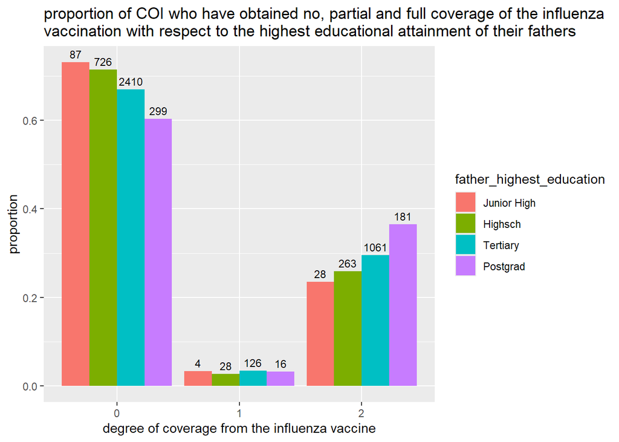

```r
# influenza vax coverage with father's highest educatioinal attainment
inf_ivd |>
  filter(!is.na(influenza_coverage_age) & !is.na(father_highest_education)) |>
  summarise(count = n(), .by = c(father_highest_education, influenza_coverage_age)) |>
  mutate(proportion = count/sum(count), .by = father_highest_education) |>

  ggplot(aes(x = influenza_coverage_age, y = proportion)) +
  geom_col(aes(fill = father_highest_education), position = "dodge") +
  function_plot_label_count(father_highest_education, coverage = influenza_coverage_age) +
  labs(title = "proportion of COI who have obtained no, partial and full coverage of the influenza\nvaccination with respect to the highest educational attainment of their fathers") +
  xlab("degree of coverage from the influenza vaccine")
```

Comparing parents, a higher educational attainment of the mother seems to be more influential on the increase in the uptake of vaccines as opposed to the highest educational attainment of the father. e.g.the increase in full covid and influenza coverage for COI of mother’s who have a postgraduate education are higher than that of fathers

A Tertiary education for mothers of the child of interest is associated with an increase in the uptake of the influenza vaccine but not for the covid vaccine. A postrgarduate education is associated with a significantly higher uptake of the influenza vaccine than a tertiary education

Education levels seem to have a larger impact on Influenza vaccination uptake than covid vaccination uptake

**Do different combinations of a child’s father’s and mother’s educational attainments affect their uptake of the child’s covid and influenza vaccination**

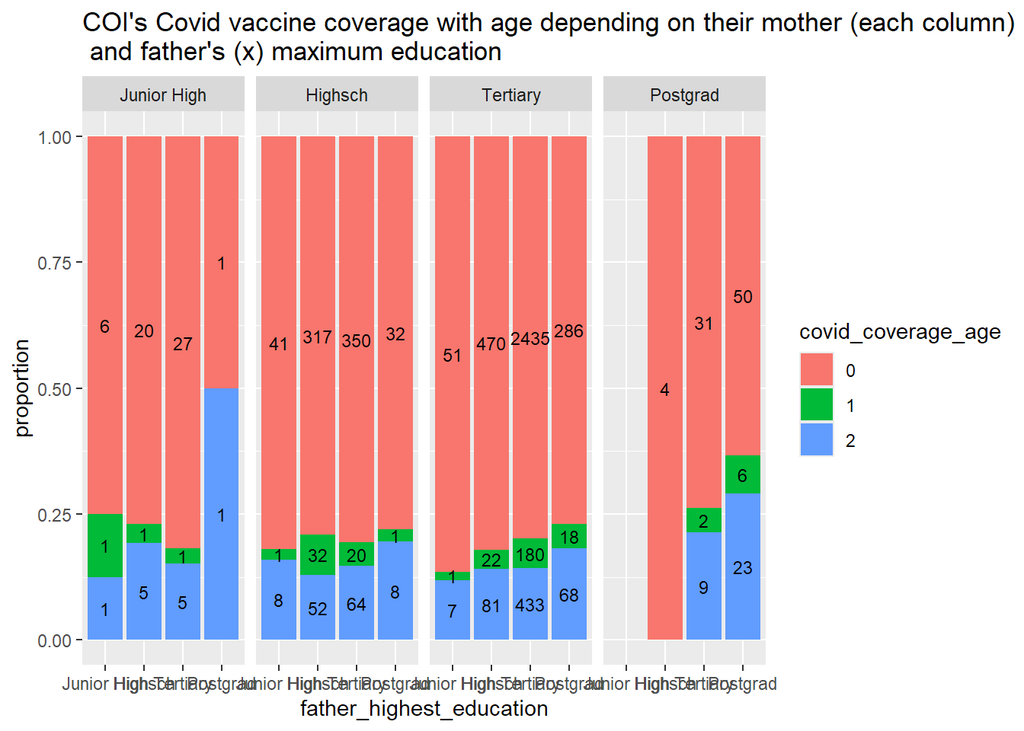

```r
# examine how covid vaccine coverage in the COI varies with different combinations of educational attainment
cov_ivd |>
  filter(
    child_of_interest == 1 & !is.na(covid_coverage_age) &
    !is.na(mother_highest_education) & !is.na(father_highest_education)
  ) |>
  summarise(count = n(), .by = c(mother_highest_education, father_highest_education, covid_coverage_age)) |>
  mutate(proportion = count/sum(count), .by = c(mother_highest_education, father_highest_education)) -> cov_age_father_mother_ed

# Covid vax uptake, varying mother's highest educational attainment for each educational attainment of the father
cov_age_father_mother_ed |>
  ggplot(aes(x = father_highest_education , y = proportion)) +
  geom_col(aes(fill = covid_coverage_age)) +
  facet_grid(cols = vars(mother_highest_education)) +
  labs(title = "COI's Covid vaccine coverage with age depending on their mother (each column) \n and father's (x) maximum education") +
  geom_text(aes(group = covid_coverage_age, label = count), position = position_fill(vjust = 0.5), size = 3)
```

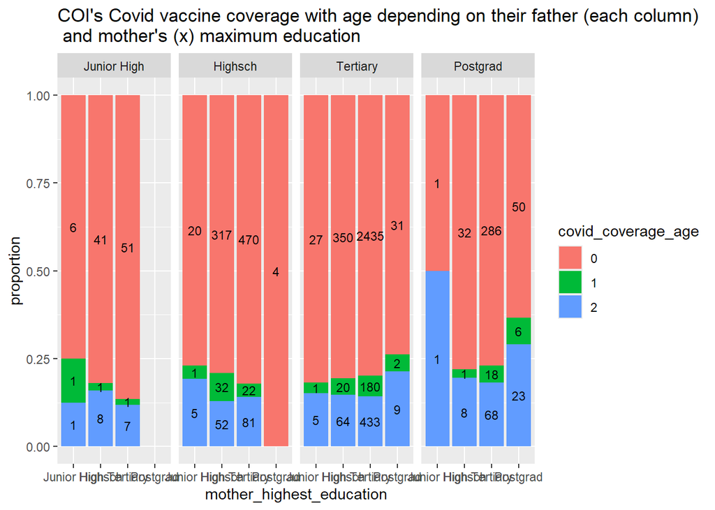

```r
# Covid vax uptake, varying father's highest educational attainment for each educational attainment of the mother
cov_age_father_mother_ed |>
  ggplot(aes(x = mother_highest_education , y = proportion)) +
  geom_col(aes(fill = covid_coverage_age)) +
  facet_grid(cols = vars(father_highest_education)) +
  labs(title = "COI's Covid vaccine coverage with age depending on their father (each column) \n and mother's (x) maximum education") +
  geom_text(aes(group = covid_coverage_age, label = count), position = position_fill(vjust = 0.5), size = 3)
```

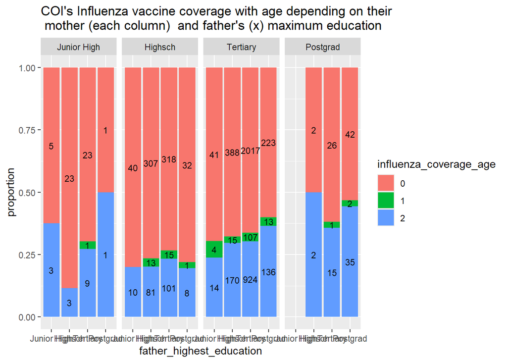

```r
# examine how influenza vaccine coverage in the COI varies with different combinations of educational attainment
inf_ivd |>
  filter(
    child_of_interest == 1 & !is.na(influenza_coverage_age) &
    !is.na(mother_highest_education) & !is.na(father_highest_education)) |>
  mutate(
    mother_highest_education = factor(mother_highest_education),
    father_highest_education = factor(father_highest_education)
  ) |>
  summarise(count = n(), .by = c(mother_highest_education, father_highest_education, influenza_coverage_age)) |>
  mutate(proportion = count/sum(count), .by = c(mother_highest_education, father_highest_education)) -> inf_age_father_mother_ed

# influenza vax uptake, varying mother's highest educational attainment for each educational attainment of the father
inf_age_father_mother_ed |>
  ggplot(aes(x = father_highest_education , y = proportion)) +
  geom_col(aes(fill = influenza_coverage_age)) +
  facet_grid(cols = vars(mother_highest_education), drop = TRUE) +
  labs(title = "COI's Influenza vaccine coverage with age depending on their \n mother (each column)  and father's (x) maximum education") +
  geom_text(aes(group = influenza_coverage_age, label = count), position = position_fill(vjust = 0.5), size = 3)
```

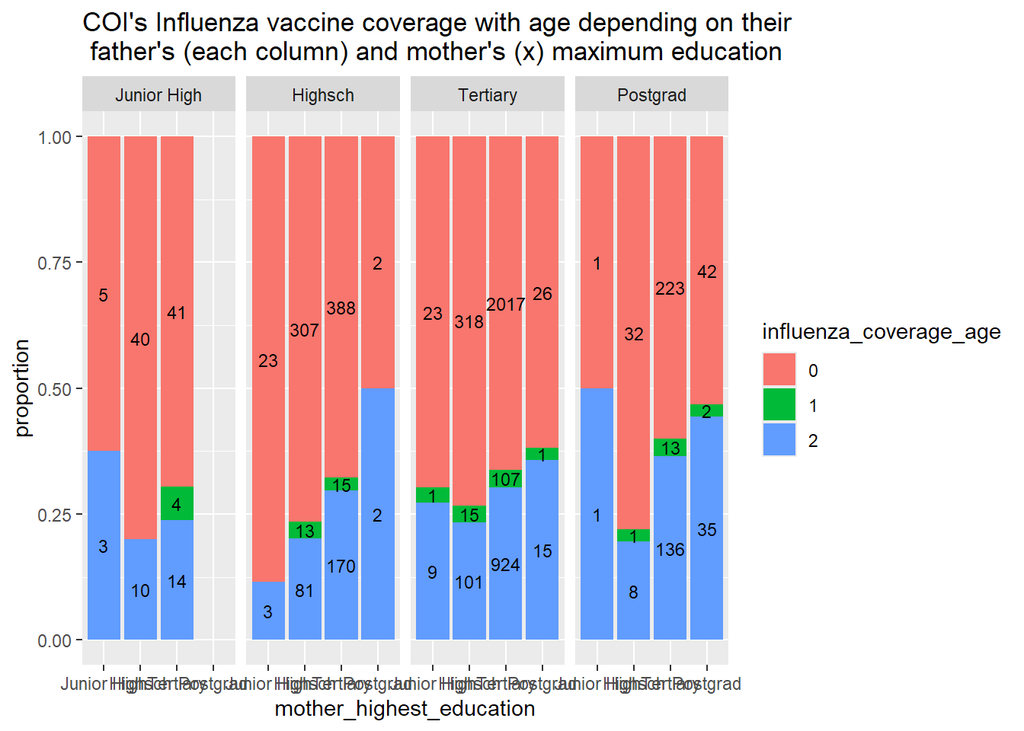

```r
# influenza vax uptake, varying father's highest educational attainment for each educational attainment of the mother
inf_age_father_mother_ed |>
  ggplot(aes(x = mother_highest_education, y = proportion)) +
  geom_col(aes(x = mother_highest_education , y = proportion, fill = influenza_coverage_age)) +
  facet_grid(cols = vars(father_highest_education), drop = TRUE) +
  labs(title = "COI's Influenza vaccine coverage with age depending on their \n father's (each column) and mother's (x) maximum education") +
  geom_text(aes(group = influenza_coverage_age, label = count), position = position_fill(vjust = 0.5), size = 3)
```

Furthermore, education elvels do seem to have a greater impact on the uptake of influenza vaccines as opposed to the uptake of covid vaccines.

## Child’s parent’s vaccination

### Parent’s influenza vaccination

*Does the influenza vaccination status of a child’s parents in the past year affect:* **The child’s influenza vaccination status**

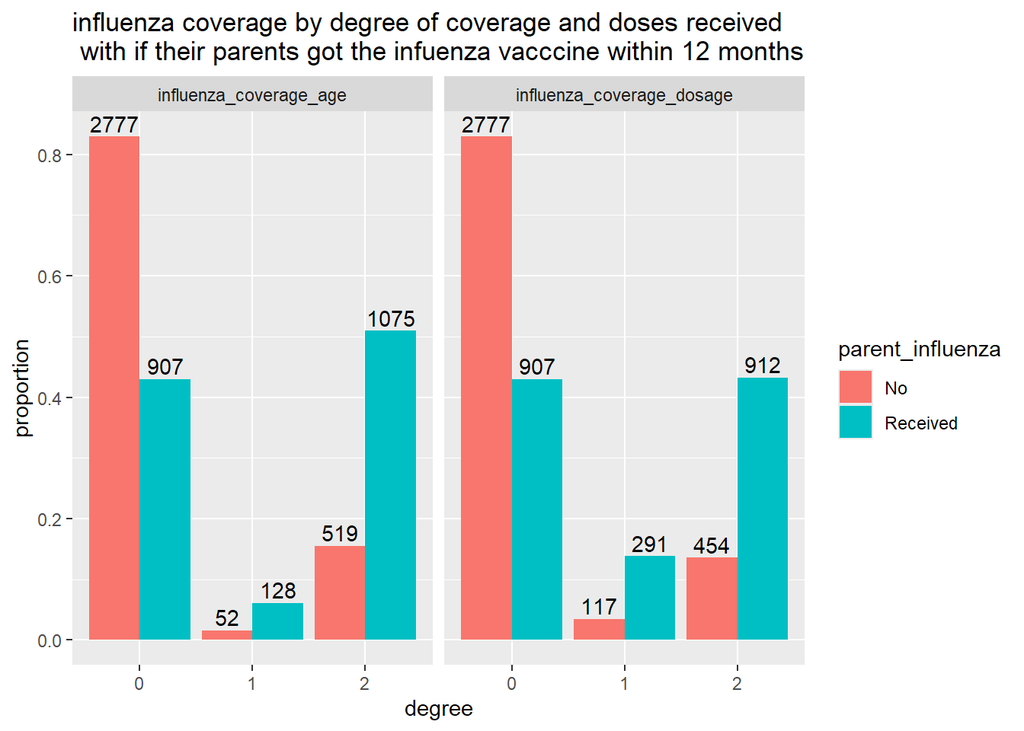

```r
inf_ivd |>
  filter(!is.na(parent_influenza) & !is.na(influenza_coverage_dosage)) |>
  pivot_longer(
    cols = c(influenza_coverage_dosage, influenza_coverage_age),
    values_to = "degree",
    names_to = "type_of_coverage"
  ) |>
  summarise(count = n(), .by = c(degree, type_of_coverage, parent_influenza)) |>
  mutate(proportion = count/sum(count), .by = c(type_of_coverage, parent_influenza)) |>

  ggplot(aes(x = degree, y = proportion)) +
  facet_wrap(vars(type_of_coverage)) +
  geom_col(aes(fill = parent_influenza), position = "dodge") +
  geom_text(aes(group = parent_influenza, label = count), position = position_dodge(width = 0.9), vjust = -0.3) +
  scale_fill_discrete(
    labels = c("0" = "No",
               "1" = "Received")
  ) +
  labs(title = "influenza coverage by degree of coverage and doses received \n with if their parents got the infuenza vacccine within 12 months")
```

*The covid vaccine*

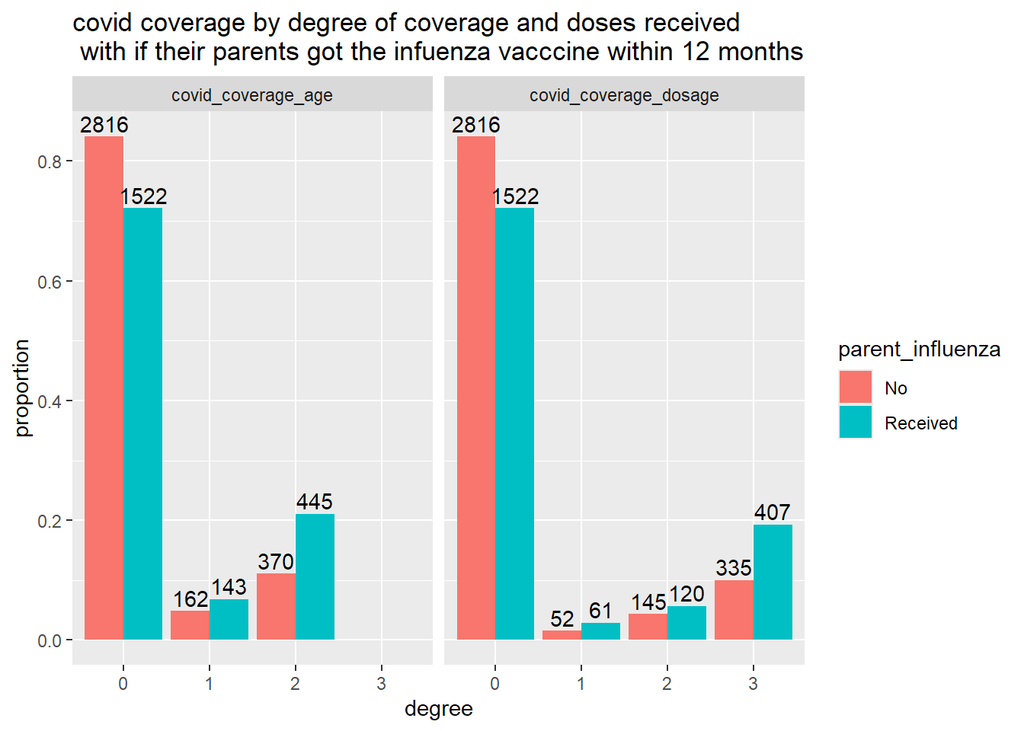

```r
cov_ivd |>
  filter(!is.na(parent_influenza) & !is.na(covid_coverage_dosage)) |>
  pivot_longer(
    cols = c(covid_coverage_dosage, covid_coverage_age),
    values_to = "degree",
    names_to = "type_of_coverage"
  ) |>
  summarise(count = n(), .by = c(degree, type_of_coverage, parent_influenza)) |>
  mutate(proportion = count/sum(count), .by = c(type_of_coverage, parent_influenza)) |>

  ggplot(aes(x = degree, y = proportion)) +
  facet_wrap(vars(type_of_coverage)) +
  geom_col(aes(fill = parent_influenza), position = "dodge") +
  geom_text(aes(group = parent_influenza, label = count), position = position_dodge(width = 0.9), vjust = -0.3) +
  scale_fill_discrete(
    labels = c("0" = "No",
               "1" = "Received")
  ) +
  labs(title = "covid coverage by degree of coverage and doses received \n with if their parents got the infuenza vacccine within 12 months")
```

A child’s parents of interest receiving the influenza vaccine in the past 12 months is positively associated with the child’s uptake of the covid and influenza vaccine. Though the effect is much more pronounced with regards to the child receiving the influenza vaccine

### Parent’s covid vaccination (dosage)

*Does the covid vaccination status of a child’s parents affect* *The child’s uptake of the covid vaccination*

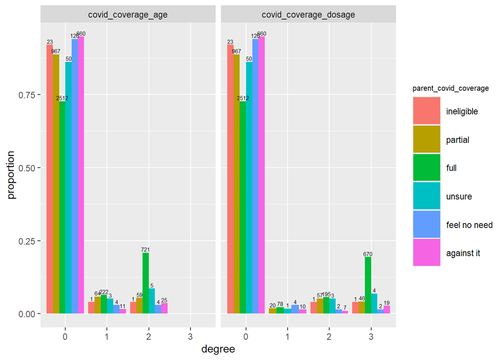

```r
cov_ivd |>
  filter(!is.na(parent_covid_coverage) & !is.na(covid_coverage_dosage)) |>
  pivot_longer(
    cols = c(covid_coverage_dosage, covid_coverage_age),
    values_to = "degree",
    names_to = "type_of_coverage"
  ) |>
  summarise(count = n(), .by = c(degree, type_of_coverage, parent_covid_coverage)) |>
  mutate(proportion = count/sum(count), .by = c(type_of_coverage, parent_covid_coverage)) |>

  ggplot(aes(x = degree, y = proportion)) +
  facet_wrap(vars(type_of_coverage)) +
  geom_col(aes(fill = parent_covid_coverage), position = "dodge") +
  geom_text(aes(group = parent_covid_coverage, label = count), position = position_dodge(width = 0.9), vjust = -0.3, size = 2) +
  scale_fill_discrete(
    labels = c("0" = "ineligible",
               "1" = "partial",
               "2" =  "full",
               "3" = "unsure",
               "4" = "feel no need",
               "5" = "against it")
  ) +
  theme(legend.key.size = unit(1, "cm"),
        legend.title = element_text(size = 7.5)
  )
```

The parents having full vacination with the covid vaccination was positively assocaited with the COI receiving full coverage with the covid vaccine but the same cannot be said for parents who are partially vaccinated with the covid vaccine as it doesn’t seem to be associated with partial vaccination of their COI

*The child’s uptake of the influenza vaccine*

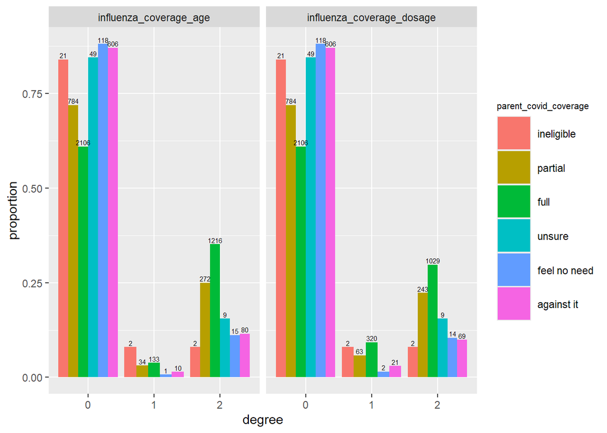

```r
inf_ivd |>
  filter(!is.na(parent_covid_coverage) & !is.na(influenza_coverage_dosage)) |>
  pivot_longer(
    cols = c(influenza_coverage_dosage, influenza_coverage_age),
    values_to = "degree",
    names_to = "type_of_coverage"
  ) |>
  summarise(count = n(), .by = c(degree, type_of_coverage, parent_covid_coverage)) |>
  mutate(proportion = count/sum(count), .by = c(type_of_coverage, parent_covid_coverage)) |>

  ggplot(aes(x = degree, y = proportion)) +
  facet_wrap(vars(type_of_coverage)) +
  geom_col(aes(fill = parent_covid_coverage), position = "dodge") +
  geom_text(aes(group = parent_covid_coverage, label = count), position = position_dodge(width = 0.9), vjust = -0.3, size = 2) +
  scale_fill_discrete(
    labels = c("0" = "ineligible",
               "1" = "partial",
               "2" =  "full",
               "3" = "unsure",
               "4" = "feel no need",
               "5" = "against it")
  ) +
  theme(legend.key.size = unit(1, "cm"),
        legend.title = element_text(size = 7.5)
  )
```